# Edelweiss EDA & Modelling - Part 2

## Edelweiss: Data Analysis and Modelling (Part 2) with Word Embeddings

## 1. Data Preprocessing

```python
import pandas as pd
import numpy as np

df=pd.read_csv('edw_launch_price_data_with_am_sp_word_embed.csv')
df.head()
```

|  | pid | b1 | b2 | b3 | b4 | b5 | b6 | b7 | b8 | zone | ... | V16 | V17 | V18 | V19 | V20 | V21 | V22 | V23 | V24 | V25 |
| --- | --- | --- | --- | --- | --- | --- | --- | --- | --- | --- | --- | --- | --- | --- | --- | --- | --- | --- | --- | --- | --- |
| 0 | 1 | 106.0 | 5.0 | NaN | NaN | NaN | NaN | NaN | NaN | Zone A | ... | -0.422871 | -0.789669 | -0.659173 | 0.189961 | 0.335592 | 1.264041 | 0.054089 | -0.131723 | -0.580872 | 0.412611 |
| 1 | 2 | NaN | 98.0 | 52.0 | NaN | NaN | NaN | NaN | NaN | Zone A | ... | -0.056276 | -0.577943 | -0.373556 | -0.023348 | 0.538932 | 0.988884 | -0.303059 | 0.348402 | -0.405855 | 0.458890 |
| 2 | 3 | NaN | 98.0 | 52.0 | NaN | NaN | NaN | NaN | NaN | Zone A | ... | -0.055074 | -0.553753 | -0.389509 | -0.025317 | 0.572751 | 1.003029 | -0.347910 | 0.379972 | -0.367028 | 0.492925 |
| 3 | 6 | 107.0 | 13.0 | NaN | NaN | NaN | NaN | NaN | NaN | Zone A | ... | -0.174178 | -0.400852 | -0.209210 | -0.201405 | 0.652291 | 1.168787 | 0.021800 | 0.150187 | -0.344659 | 0.357670 |
| 4 | 7 | 1.0 | 22.0 | 10.0 | NaN | NaN | NaN | NaN | NaN | Zone A | ... | -0.063372 | -0.468529 | -0.364467 | -0.108515 | 0.692411 | 1.022727 | -0.269232 | 0.352715 | -0.367375 | 0.468766 |

5 rows × 48 columns

#### 1.1 Creation of micro_market number and developer_number columns

```python
df['micro_market_number']=df['micro_market'].str.extract('(\d+)')
df['developer_number']=df['developer'].str.extract('(\d+)')
df['project_number']=df['project'].str.extract('(\d+)')
```

#### 1.2 Extract launch year from launch date

```python
df['launch_year'] = pd.DatetimeIndex(df['launch_date']).year
```

#### 1.3 Log-transformation of wap into log_wap

```python
df['log_wap'] = np.log(df['wap'])
```

#### 1.4 Recoding of proj_bedrooms

```python
df['proj_bedrooms'].value_counts()
```

```
1,2              1075
1                 519
1,2,3             296
2,3               241
2                 161
3                  56
2,3,4              51
3,4                39
1,2,3,4            33
3,2                17
4                  16
3,1,2              14
1,3                12
3,4,5              10
1,2,4               9
```

[output cut: 33 more lines]

```python
new_tags=['1,2,3','1,2,3,4','1,2,3,4','1,3','2,3','2,4','1,3,4','1,2,3,4,5','2,3,4,5','3,4','1,2,3,5','2,3,4','2,3,4']
old_tags=['3,1,2','4,1,2,3','2,3,4,1','3,1','3,2','4,2','4,1,3','2,3,4,5,1','5,2,3,4','4,3','2,3,5,1','4,2,3','3,4,2']

df["proj_bedrooms_clean"]=df["proj_bedrooms"]
df["proj_bedrooms_clean"]=df["proj_bedrooms_clean"].replace(old_tags,new_tags)
df["proj_bedrooms_clean"]=df["proj_bedrooms_clean"].str.split(',').str[0]
df["proj_bedrooms_clean"]=df["proj_bedrooms_clean"].replace(['1','2','3','4','5','6'],['1 and more','2 and more','3 and more','4 and more','5 and more','6 and more'])
df["proj_bedrooms_clean"].value_counts()
```

```
1 and more    1985
2 and more     498
3 and more     114
4 and more      21
6 and more       3
Name: proj_bedrooms_clean, dtype: int64
```

```python
cols=['zone', 'micro_market_number', 'developer_number','project_number','wap','log_wap','proj_bedrooms_clean','unit_type','proj_launched_units','launch_year','construction_status','max_size','min_size','b1','b2','b3','b4','b5','b6','b7','b8']
df1=pd.DataFrame(df[cols]).fillna("0")
w_emb=df.loc[:,'V1':'V25']
df1=pd.concat([df1, w_emb], axis=1)
df1.head()
```

|  | zone | micro_market_number | developer_number | project_number | wap | log_wap | proj_bedrooms_clean | unit_type | proj_launched_units | launch_year | ... | V16 | V17 | V18 | V19 | V20 | V21 | V22 | V23 | V24 | V25 |
| --- | --- | --- | --- | --- | --- | --- | --- | --- | --- | --- | --- | --- | --- | --- | --- | --- | --- | --- | --- | --- | --- |
| 0 | Zone A | 1 | 1 | 1 | 14464.0000 | 9.579418 | 1 and more | Apartment | 111 | 2015 | ... | -0.422871 | -0.789669 | -0.659173 | 0.189961 | 0.335592 | 1.264041 | 0.054089 | -0.131723 | -0.580872 | 0.412611 |
| 1 | Zone A | 1 | 2 | 2 | 13982.0000 | 9.545526 | 2 and more | Apartment | 150 | 2014 | ... | -0.056276 | -0.577943 | -0.373556 | -0.023348 | 0.538932 | 0.988884 | -0.303059 | 0.348402 | -0.405855 | 0.458890 |
| 2 | Zone A | 1 | 2 | 3 | 13982.0000 | 9.545526 | 2 and more | Apartment | 150 | 2014 | ... | -0.055074 | -0.553753 | -0.389509 | -0.025317 | 0.572751 | 1.003029 | -0.347910 | 0.379972 | -0.367028 | 0.492925 |
| 3 | Zone A | 1 | 5 | 6 | 12857.0000 | 9.461644 | 1 and more | Apartment | 120 | 2016 | ... | -0.174178 | -0.400852 | -0.209210 | -0.201405 | 0.652291 | 1.168787 | 0.021800 | 0.150187 | -0.344659 | 0.357670 |
| 4 | Zone A | 1 | 7 | 8 | 16981.5758 | 9.739884 | 1 and more | Apartment | 33 | 2015 | ... | -0.063372 | -0.468529 | -0.364467 | -0.108515 | 0.692411 | 1.022727 | -0.269232 | 0.352715 | -0.367375 | 0.468766 |

5 rows × 46 columns

#### 1.5 Type Conversion

```python
df1.info()
```

```
<class 'pandas.core.frame.DataFrame'>
RangeIndex: 2621 entries, 0 to 2620
Data columns (total 46 columns):
zone                   2621 non-null object
micro_market_number    2621 non-null object
developer_number       2621 non-null object
project_number         2621 non-null object
wap                    2621 non-null float64
log_wap                2621 non-null float64
proj_bedrooms_clean    2621 non-null object
unit_type              2621 non-null object
proj_launched_units    2621 non-null int64
launch_year            2621 non-null int64
construction_status    2621 non-null object
max_size               2621 non-null float64
min_size               2621 non-null float64
b1                     2621 non-null object
b2                     2621 non-null object
b3                     2621 non-null object
b4                     2621 non-null object
b5                     2621 non-null object
b6                     2621 non-null object
b7                     2621 non-null object
b8                     2621 non-null object
V1                     2621 non-null float64
V2                     2621 non-null float64
V3                     2621 non-null float64
V4                     2621 non-null float64
V5                     2621 non-null float64
V6                     2621 non-null float64
V7                     2621 non-null float64
V8                     2621 non-null float64
V9                     2621 non-null float64
V10                    2621 non-null float64
V11                    2621 non-null float64
V12                    2621 non-null float64
V13                    2621 non-null float64
V14                    2621 non-null float64
V15                    2621 non-null float64
V16                    2621 non-null float64
V17                    2621 non-null float64
V18                    2621 non-null float64
V19                    2621 non-null float64
V20                    2621 non-null float64
V21                    2621 non-null float64
V22                    2621 non-null float64
V23                    2621 non-null float64
V24                    2621 non-null float64
V25                    2621 non-null float64
dtypes: float64(29), int64(2), object(15)
memory usage: 942.0+ KB
```

```python
def type_converter (dataframe, col_name, data_type):
    dataframe[col_name]=dataframe[col_name].astype(data_type)
```

```python
for i in ['b1','b2','b3','b4','b5','b6','b7','b8']:
    type_converter (df1, i, 'int')
```

```python
for i in ['zone','micro_market_number','proj_bedrooms_clean','project_number','unit_type','launch_year','construction_status']:
    type_converter (df1, i, 'category')
```

```python
df1.info()
```

```
<class 'pandas.core.frame.DataFrame'>
RangeIndex: 2621 entries, 0 to 2620
Data columns (total 46 columns):
zone                   2621 non-null category
micro_market_number    2621 non-null category
developer_number       2621 non-null object
project_number         2621 non-null category
wap                    2621 non-null float64
log_wap                2621 non-null float64
proj_bedrooms_clean    2621 non-null category
unit_type              2621 non-null category
proj_launched_units    2621 non-null int64
launch_year            2621 non-null category
construction_status    2621 non-null category
max_size               2621 non-null float64
min_size               2621 non-null float64
b1                     2621 non-null int32
b2                     2621 non-null int32
b3                     2621 non-null int32
b4                     2621 non-null int32
b5                     2621 non-null int32
b6                     2621 non-null int32
b7                     2621 non-null int32
b8                     2621 non-null int32
V1                     2621 non-null float64
V2                     2621 non-null float64
V3                     2621 non-null float64
V4                     2621 non-null float64
V5                     2621 non-null float64
V6                     2621 non-null float64
V7                     2621 non-null float64
V8                     2621 non-null float64
V9                     2621 non-null float64
V10                    2621 non-null float64
V11                    2621 non-null float64
V12                    2621 non-null float64
V13                    2621 non-null float64
V14                    2621 non-null float64
V15                    2621 non-null float64
V16                    2621 non-null float64
V17                    2621 non-null float64
V18                    2621 non-null float64
V19                    2621 non-null float64
V20                    2621 non-null float64
V21                    2621 non-null float64
V22                    2621 non-null float64
V23                    2621 non-null float64
V24                    2621 non-null float64
V25                    2621 non-null float64
dtypes: category(7), float64(29), int32(8), int64(1), object(1)
memory usage: 842.8+ KB
```

#### 1.6 Creation of bedrooms by typology columns

```python
df1['bp1']=df1['b1']/df1['proj_launched_units']
df1['bp2']=df1['b2']/df1['proj_launched_units']
df1['bp3']=df1['b3']/df1['proj_launched_units']
df1['bp4']=df1['b4']/df1['proj_launched_units']
df1['bp5']=df1['b5']/df1['proj_launched_units']
df1['bp6']=df1['b6']/df1['proj_launched_units']
df1['bp7']=df1['b7']/df1['proj_launched_units']
df1['bp8']=df1['b8']/df1['proj_launched_units']
```

```python
df1['bp48']=df1['bp4']+df1['bp5']+df1['bp6']+df1['bp7']+df1['bp8']
df1['bp58']=df1['bp5']+df1['bp6']+df1['bp7']+df1['bp8']
```

#### 1.7 rv_size column

```python
df1['size_range'] = df1['max_size'] - df1['min_size']
df1['size_rv'] = df1['size_range'] / df1['min_size']
```

## 2. Data and Cluster Analysis

### 2.1 Cluster Analysis of Micromarkets

1. K-Means Clustering based on mean of wap for every micromarket
2. Assigning cluster numbers to respective micro_markets
3. Counting number of projects and micromarkets in every cluster

```python
import matplotlib.pyplot as plt
import seaborn as sns
%matplotlib inline

sns.set(style="darkgrid")
sns.set_color_codes("dark")
```

```python
mm_prices=df1.groupby('micro_market_number')['wap'].mean()
mm_prices
```

```
micro_market_number
1      16070.897978
10     12709.734924
100     6730.000000
101     4800.454082
102     7601.348358
104     4550.000000
105     9666.666667
106     5561.967821
107     8028.775714
108    10951.648586
109     4281.954455
11     13484.938329
110     5600.885779
111    15000.000000
```

[output cut: 48 more lines]

```python
mm_prices.shape
```

```
(113,)
```

```python
mm=mm_prices.values
mm=mm.reshape(-1, 1)
mm.shape
```

```
(113, 1)
```

```python
from sklearn.cluster import KMeans

#clustering formula
kmeans = KMeans(n_clusters=20, n_init=100, max_iter=1000,n_jobs=5)

# get the clusters
kmm = kmeans.fit_predict(mm)

#clustering metric
from sklearn.metrics import silhouette_score
print("Silhoutte Score of Micromarket Clusters:", silhouette_score(mm, kmm))
```

```
Silhoutte Score of Micromarket Clusters: 0.659594734571081
```

```python
#cluster dataframe
kmm=pd.DataFrame(kmm)
kmm.columns=['mm_cluster']

#cluster number and number of projects for every micromarket
mm_proj=df1.groupby('micro_market_number')['project_number'].count().reset_index()
mm_proj=pd.concat([mm_proj, kmm],axis=1)
mm_proj
```

|  | micro_market_number | project_number | mm_cluster |
| --- | --- | --- | --- |
| 0 | 1 | 49 | 6 |
| 1 | 10 | 12 | 1 |
| 2 | 100 | 5 | 13 |
| 3 | 101 | 49 | 18 |
| 4 | 102 | 33 | 13 |
| 5 | 104 | 2 | 18 |
| 6 | 105 | 3 | 7 |
| 7 | 106 | 55 | 19 |
| 8 | 107 | 7 | 13 |
| 9 | 108 | 14 | 17 |
| 10 | 109 | 49 | 3 |
| 11 | 11 | 28 | 1 |
| 12 | 110 | 129 | 19 |
| 13 | 111 | 1 | 15 |
| 14 | 112 | 1 | 10 |
| 15 | 113 | 3 | 18 |
| 16 | 114 | 181 | 17 |
| 17 | 115 | 9 | 8 |
| 18 | 116 | 13 | 0 |
| 19 | 118 | 5 | 5 |
| 20 | 119 | 15 | 11 |
| 21 | 12 | 27 | 1 |
| 22 | 120 | 8 | 11 |
| 23 | 121 | 26 | 4 |
| 24 | 122 | 18 | 5 |
| 25 | 123 | 33 | 12 |
| 26 | 124 | 10 | 16 |
| 27 | 13 | 52 | 15 |
| 28 | 14 | 2 | 10 |
| 29 | 15 | 3 | 10 |
| ... | ... | ... | ... |
| 83 | 69 | 46 | 10 |
| 84 | 7 | 27 | 15 |
| 85 | 70 | 7 | 10 |
| 86 | 72 | 50 | 18 |
| 87 | 73 | 32 | 18 |
| 88 | 75 | 95 | 14 |
| 89 | 76 | 6 | 6 |
| 90 | 77 | 4 | 14 |
| 91 | 79 | 8 | 14 |
| 92 | 8 | 15 | 6 |
| 93 | 80 | 2 | 4 |
| 94 | 81 | 1 | 0 |
| 95 | 82 | 12 | 8 |
| 96 | 84 | 12 | 16 |
| 97 | 85 | 8 | 16 |
| 98 | 86 | 11 | 8 |
| 99 | 87 | 5 | 12 |
| 100 | 88 | 5 | 2 |
| 101 | 89 | 2 | 2 |
| 102 | 9 | 21 | 15 |
| 103 | 90 | 1 | 12 |
| 104 | 91 | 5 | 4 |
| 105 | 92 | 5 | 12 |
| 106 | 93 | 3 | 9 |
| 107 | 94 | 4 | 9 |
| 108 | 95 | 4 | 17 |
| 109 | 96 | 5 | 19 |
| 110 | 97 | 40 | 3 |
| 111 | 98 | 11 | 7 |
| 112 | 99 | 5 | 19 |

113 rows × 3 columns

```python
# Dictionary mapping micromarket number with cluster numbers
market_cluster = dict(zip(mm_proj['micro_market_number'], mm_proj['mm_cluster']))
```

```python
# Create a new column in the dataset indicating cluster numbers, initialised with micromarket numbers
df1['mm_cluster']=df1['micro_market_number']
# Map cluster numbers to their respective micromarket numbers
df1['mm_cluster']=df1['mm_cluster'].map(market_cluster)
df1['mm_cluster'].value_counts()
```

```
10    559
19    347
17    230
15    218
3     202
18    192
6     187
1     129
13    126
14    124
4      87
12     46
5      42
8      32
16     30
11     23
7      19
0      14
9       7
2       7
Name: mm_cluster, dtype: int64
```

```python
# How many projects are there for each cluster?
kmm_proj=df1.groupby('mm_cluster')['project_number'].count().reset_index()
kmm_proj=pd.DataFrame(kmm_proj)
kmm_proj
```

|  | mm_cluster | project_number |
| --- | --- | --- |
| 0 | 0 | 14 |
| 1 | 1 | 129 |
| 2 | 2 | 7 |
| 3 | 3 | 202 |
| 4 | 4 | 87 |
| 5 | 5 | 42 |
| 6 | 6 | 187 |
| 7 | 7 | 19 |
| 8 | 8 | 32 |
| 9 | 9 | 7 |
| 10 | 10 | 559 |
| 11 | 11 | 23 |
| 12 | 12 | 46 |
| 13 | 13 | 126 |
| 14 | 14 | 124 |
| 15 | 15 | 218 |
| 16 | 16 | 30 |
| 17 | 17 | 230 |
| 18 | 18 | 192 |
| 19 | 19 | 347 |

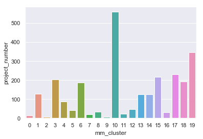

```python
# projects per cluster
sns.barplot(x="mm_cluster", y="project_number", data=kmm_proj)
```

```python
# Number of micromarkets in each micromarket cluster
kmm_micro=mm_proj.groupby('mm_cluster')['micro_market_number'].count().reset_index()
kmm_micro=pd.DataFrame(kmm_micro)
kmm_micro
```

|  | mm_cluster | micro_market_number |
| --- | --- | --- |
| 0 | 0 | 2 |
| 1 | 1 | 6 |
| 2 | 2 | 2 |
| 3 | 3 | 9 |
| 4 | 4 | 5 |
| 5 | 5 | 3 |
| 6 | 6 | 6 |
| 7 | 7 | 4 |
| 8 | 8 | 3 |
| 9 | 9 | 2 |
| 10 | 10 | 23 |
| 11 | 11 | 2 |
| 12 | 12 | 5 |
| 13 | 13 | 6 |
| 14 | 14 | 4 |
| 15 | 15 | 9 |
| 16 | 16 | 3 |
| 17 | 17 | 4 |
| 18 | 18 | 9 |
| 19 | 19 | 6 |

```python
year_mm_price=df1.groupby(['launch_year','mm_cluster'])['wap'].mean()
year_mm_price=pd.DataFrame(year_mm_price)

mean_wap_by_year=pd.concat([year_mm_price.loc[(2014)],year_mm_price.loc[(2015)],year_mm_price.loc[(2016)],year_mm_price.loc[(2017)],year_mm_price.loc[(2018)]],axis=1)
mean_wap_by_year.columns=['meanwap_2014','meanwap_2015','meanwap_2016','meanwap_2017','meanwap_2018']
mean_wap_by_year
```

| mm_cluster | meanwap_2014 | meanwap_2015 | meanwap_2016 | meanwap_2017 | meanwap_2018 |
| --- | --- | --- | --- | --- | --- |
| 0 | 41070.750000 | 52483.166667 | 64374.666667 | 15714.000000 | NaN |
| 1 | 12218.709031 | 13146.632946 | 12832.710219 | 13602.809310 | 13159.716422 |
| 2 | NaN | 35000.000000 | 33000.000000 | 27220.483133 | 29757.626415 |
| 3 | 4103.807960 | 4034.626387 | 4166.287660 | 4653.439452 | 4005.434851 |
| 4 | 18810.414848 | 18559.228896 | 20928.727273 | 24918.370369 | 22168.930146 |
| 5 | 35808.407242 | 42769.880344 | 38872.774000 | 35593.090909 | NaN |
| 6 | 15442.331257 | 16442.129733 | 17007.092950 | 16575.809007 | 16303.168679 |
| 7 | 9100.000000 | 9265.000000 | 9033.200000 | 9276.500000 | NaN |
| 8 | 25540.571429 | 24137.198489 | 26291.311667 | 22824.759933 | 26730.000000 |
| 9 | 36130.666667 | 37999.500000 | 55858.000000 | NaN | NaN |
| 10 | 2984.480692 | 3023.583100 | 3159.066072 | 3250.648610 | 3179.228021 |
| 11 | 34678.250000 | 34907.799386 | 33380.333333 | 32685.333333 | NaN |
| 12 | 28082.162960 | 26854.000000 | 28538.773155 | 27601.714286 | NaN |
| 13 | 7241.750000 | 7190.230312 | 6923.446786 | 7284.184616 | 8434.699402 |
| 14 | 18112.103745 | 17384.851852 | 17553.483153 | 17890.197668 | 17814.555000 |
| 15 | 14098.454837 | 14831.488343 | 14715.145918 | 15174.651398 | 15406.955109 |
| 16 | 29000.000000 | 31921.800000 | 32120.569167 | 30106.800000 | NaN |
| 17 | 9485.603483 | 11429.214727 | 9672.252469 | 9846.522545 | 11802.490392 |
| 18 | 4461.157143 | 4607.763853 | 4907.938194 | 5429.623377 | 5805.102328 |
| 19 | 5245.697588 | 5253.664460 | 5337.699442 | 5756.918935 | 8158.254843 |

```python
from scipy.stats import spearmanr

rho, pval = spearmanr(mean_wap_by_year,nan_policy='omit')
rho = pd.DataFrame(rho)
rho.index=['meanwap_2014','meanwap_2015','meanwap_2016','meanwap_2017','meanwap_2018']
rho.columns=['meanwap_2014','meanwap_2015','meanwap_2016','meanwap_2017','meanwap_2018']
rho
```

|  | meanwap_2014 | meanwap_2015 | meanwap_2016 | meanwap_2017 | meanwap_2018 |
| --- | --- | --- | --- | --- | --- |
| meanwap_2014 | 1.000000 | 0.998246 | 1.000000 | 0.923633 | 1.000000 |
| meanwap_2015 | 0.998246 | 1.000000 | 0.996992 | 0.908772 | 1.000000 |
| meanwap_2016 | 1.000000 | 0.996992 | 1.000000 | 0.914035 | 1.000000 |
| meanwap_2017 | 0.923633 | 0.908772 | 0.914035 | 1.000000 | 0.994505 |
| meanwap_2018 | 1.000000 | 1.000000 | 1.000000 | 0.994505 | 1.000000 |

The micromarket clusters are stable given the high value of Spearman correlation coefficients.

### 2.2 Clustering Developers

```python
devn_prices=df1.groupby('developer_number')['wap'].mean()
devn_prices
```

```
developer_number
1       14464.000000
10      12610.000000
100     15750.000000
1000     3000.000000
1002     4500.000000
1003     4171.000000
1004     4500.000000
1006     5650.000000
1007     5662.000000
1008     5657.580600
101     18500.000000
1011     9642.000000
1012     5000.000000
1014    10850.000000
```

[output cut: 48 more lines]

The number of developers is too large to be used as a variable for regression model. Let's cluster developers in terms of prices. Let us try agglomerative clustering this time.

```python
devn_prices.shape
```

```
(1504,)
```

```python
devn=devn_prices.values # Reshape the array consisting of data with one feature into one column only
devn=devn.reshape(-1, 1)
devn.shape
```

```
(1504, 1)
```

```
[Text(0, 0.5, 'Inter-cluster distance'), Text(0.5, 1.0, 'Dendrogram')]
```

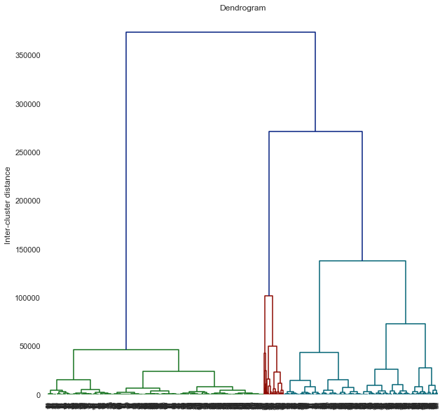

```python
# for visualisation for hierarchal cluster linkage
from scipy.cluster.hierarchy import dendrogram, linkage

links = linkage(devn, method='ward', metric='euclidean')

fig, ax = plt.subplots(figsize=(10, 10))
dendrogram(links, ax=ax)

ax.set(title='Dendrogram', ylabel='Inter-cluster distance')
```

```python
from sklearn.cluster import AgglomerativeClustering

agg = AgglomerativeClustering(n_clusters=20,linkage='ward')
clusters_agg = agg.fit_predict(devn)

print("Silhoutte Score of Developer Clusters:", silhouette_score(devn, clusters_agg))
```

```
Silhoutte Score of Developer Clusters: 0.5551048139920645
```

```python
#cluster dataframe
clusters_agg =pd.DataFrame(clusters_agg)
clusters_agg .columns=['dev_cluster']

#cluster number and number of projects for every micromarket
dev_proj=df1.groupby('developer_number')['project_number'].count().reset_index()
dev_proj=pd.concat([dev_proj, clusters_agg ],axis=1)
dev_proj
```

|  | developer_number | project_number | dev_cluster |
| --- | --- | --- | --- |
| 0 | 1 | 1 | 16 |
| 1 | 10 | 1 | 3 |
| 2 | 100 | 2 | 11 |
| 3 | 1000 | 1 | 4 |
| 4 | 1002 | 1 | 13 |
| 5 | 1003 | 1 | 13 |
| 6 | 1004 | 1 | 13 |
| 7 | 1006 | 1 | 8 |
| 8 | 1007 | 1 | 8 |
| 9 | 1008 | 1 | 8 |
| 10 | 101 | 1 | 2 |
| 11 | 1011 | 1 | 6 |
| 12 | 1012 | 1 | 8 |
| 13 | 1014 | 2 | 18 |
| 14 | 1017 | 3 | 13 |
| 15 | 1018 | 1 | 17 |
| 16 | 1019 | 1 | 6 |
| 17 | 102 | 4 | 6 |
| 18 | 1020 | 2 | 6 |
| 19 | 1021 | 1 | 13 |
| 20 | 1023 | 2 | 13 |
| 21 | 1025 | 1 | 13 |
| 22 | 1026 | 1 | 8 |
| 23 | 1029 | 2 | 13 |
| 24 | 1030 | 3 | 8 |
| 25 | 1031 | 1 | 18 |
| 26 | 1032 | 1 | 13 |
| 27 | 1033 | 2 | 13 |
| 28 | 1035 | 3 | 13 |
| 29 | 1037 | 1 | 13 |
| ... | ... | ... | ... |
| 1474 | 947 | 1 | 4 |
| 1475 | 949 | 1 | 13 |
| 1476 | 952 | 1 | 8 |
| 1477 | 956 | 1 | 4 |
| 1478 | 957 | 4 | 4 |
| 1479 | 959 | 1 | 4 |
| 1480 | 96 | 6 | 11 |
| 1481 | 960 | 3 | 18 |
| 1482 | 962 | 1 | 13 |
| 1483 | 963 | 1 | 4 |
| 1484 | 965 | 1 | 8 |
| 1485 | 967 | 1 | 8 |
| 1486 | 968 | 1 | 13 |
| 1487 | 970 | 1 | 13 |
| 1488 | 971 | 2 | 3 |
| 1489 | 972 | 1 | 13 |
| 1490 | 976 | 2 | 13 |
| 1491 | 978 | 2 | 13 |
| 1492 | 979 | 2 | 13 |
| 1493 | 982 | 1 | 13 |
| 1494 | 985 | 1 | 13 |
| 1495 | 989 | 1 | 17 |
| 1496 | 99 | 1 | 2 |
| 1497 | 991 | 1 | 17 |
| 1498 | 992 | 1 | 13 |
| 1499 | 993 | 1 | 13 |
| 1500 | 994 | 2 | 8 |
| 1501 | 995 | 1 | 13 |
| 1502 | 996 | 1 | 8 |
| 1503 | 999 | 1 | 13 |

1504 rows × 3 columns

```python
# Dictionary mapping micromarket number with cluster numbers
dev_cluster = dict(zip(dev_proj['developer_number'], dev_proj['dev_cluster']))
```

```python
# Create a new column in the dataset indicating cluster numbers, initialised with micromarket numbers
df1['dev_cluster']=df1['developer_number']
# Map cluster numbers to their respective micromarket numbers
df1['dev_cluster']=df1['dev_cluster'].map(dev_cluster)
print('value counts of developer clusters')
df1['dev_cluster'].value_counts()
```

```
value counts of developer clusters
```

```
4     491
13    412
8     246
11    198
6     190
3     181
17    172
18    154
2     147
16    138
10    125
5      74
14     24
7      21
9      16
1      16
12      6
15      6
0       3
19      1
Name: dev_cluster, dtype: int64
```

The frequency counts of projects in certain developer clusters are low. Let us merge cluster 0, 12 and 19 with cluster 15.

```python
df1['dev_cluster']=df1['dev_cluster'].replace([19,0,12],[15,15,15])
df1['dev_cluster'].value_counts()
```

```
4     491
13    412
8     246
11    198
6     190
3     181
17    172
18    154
2     147
16    138
10    125
5      74
14     24
7      21
15     16
9      16
1      16
Name: dev_cluster, dtype: int64
```

```python
# How many projects are there for each cluster?
clusters_agg_proj=df1.groupby('dev_cluster')['project_number'].count().reset_index()
clusters_agg_proj=pd.DataFrame(clusters_agg_proj)
clusters_agg_proj
```

|  | dev_cluster | project_number |
| --- | --- | --- |
| 0 | 1 | 16 |
| 1 | 2 | 147 |
| 2 | 3 | 181 |
| 3 | 4 | 491 |
| 4 | 5 | 74 |
| 5 | 6 | 190 |
| 6 | 7 | 21 |
| 7 | 8 | 246 |
| 8 | 9 | 16 |
| 9 | 10 | 125 |
| 10 | 11 | 198 |
| 11 | 13 | 412 |
| 12 | 14 | 24 |
| 13 | 15 | 16 |
| 14 | 16 | 138 |
| 15 | 17 | 172 |
| 16 | 18 | 154 |

Let's check if clusters for developers are stable or not with the help of spearman's correlation ranking just like mm clusters.

```python
year_dev_price=df1.groupby(['launch_year','dev_cluster'])['wap'].mean()
year_dev_price=pd.DataFrame(year_dev_price)

meanwap_dev_year=pd.concat([year_dev_price.loc[(2014)],year_dev_price.loc[(2015)],year_dev_price.loc[(2016)],year_dev_price.loc[(2017)],year_dev_price.loc[(2018)]],axis=1)
meanwap_dev_year.columns=['dev_meanwap_2014','dev_meanwap_2015','dev_meanwap_2016','dev_meanwap_2017','dev_meanwap_2018']
meanwap_dev_year
```

| dev_cluster | dev_meanwap_2014 | dev_meanwap_2015 | dev_meanwap_2016 | dev_meanwap_2017 | dev_meanwap_2018 |
| --- | --- | --- | --- | --- | --- |
| 1 | 34523.333333 | 44083.666667 | 40356.500000 | 40475.666667 | NaN |
| 2 | 18618.484114 | 18223.293813 | 18663.114653 | 18450.660030 | 20253.878407 |
| 3 | 11923.177869 | 12458.979720 | 11422.621458 | 13092.890102 | 14102.444743 |
| 4 | 2972.444447 | 2980.337878 | 2943.888492 | 3049.169011 | 3029.044720 |
| 5 | 28869.048530 | 21245.646832 | 24528.580973 | 26155.944973 | 19951.965000 |
| 6 | 7893.894020 | 9205.310800 | 8838.696505 | 9658.908851 | 9393.874231 |
| 7 | 27741.400000 | 27022.050000 | 33676.956667 | 29428.200000 | NaN |
| 8 | 5284.542853 | 5331.455128 | 5547.145254 | 5658.106230 | 5754.399869 |
| 9 | NaN | 34352.000000 | 31200.978333 | 32499.250000 | NaN |
| 10 | 20579.105400 | 21804.879129 | 24008.702998 | 20462.333333 | 22090.275553 |
| 11 | 16041.288125 | 15734.554135 | 15715.275855 | 17161.241315 | 14046.844324 |
| 13 | 4306.481880 | 4106.793313 | 4352.505776 | 4490.517484 | 4698.274251 |
| 14 | 35534.291675 | 35925.400000 | 35237.858000 | 35513.400000 | NaN |
| 15 | 50714.000000 | 52941.199463 | 64875.185000 | 48544.000000 | NaN |
| 16 | 14180.310176 | 13364.358875 | 14775.979770 | 14245.437278 | 13669.393405 |
| 17 | 7051.595813 | 7140.349544 | 6967.973769 | 6443.485685 | 5389.249678 |
| 18 | 11139.850179 | 11394.718146 | 9060.299972 | 9480.421491 | 15471.097748 |

```python
from scipy.stats import spearmanr

rho1, pval1 = spearmanr(meanwap_dev_year, nan_policy='omit') # rho1 - correlation coefficient, p-val1 - p-value signifying monotonic relationship
rho1 = pd.DataFrame(rho1)
rho1.index=['dev_meanwap_2014','dev_meanwap_2015','dev_meanwap_2016','dev_meanwap_2017','dev_meanwap_2018']
rho1.columns=['dev_meanwap_2014','dev_meanwap_2015','dev_meanwap_2016','dev_meanwap_2017','dev_meanwap_2018']
rho1
```

|  | dev_meanwap_2014 | dev_meanwap_2015 | dev_meanwap_2016 | dev_meanwap_2017 | dev_meanwap_2018 |
| --- | --- | --- | --- | --- | --- |
| dev_meanwap_2014 | 1.000000 | 0.988235 | 0.994118 | 0.991176 | 0.909091 |
| dev_meanwap_2015 | 0.988235 | 1.000000 | 0.995098 | 0.995098 | 0.923077 |
| dev_meanwap_2016 | 0.994118 | 0.995098 | 1.000000 | 0.995098 | 0.909091 |
| dev_meanwap_2017 | 0.991176 | 0.995098 | 0.995098 | 1.000000 | 0.881119 |
| dev_meanwap_2018 | 0.909091 | 0.923077 | 0.909091 | 0.881119 | 1.000000 |

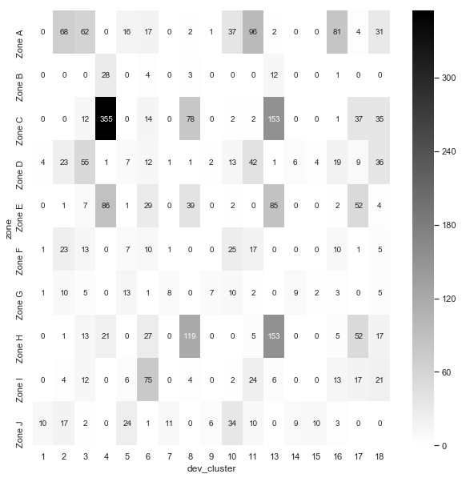

```python
fig,ax=plt.subplots(figsize=(10,10))
fig=sns.heatmap(pd.crosstab(df1['zone'], df1['dev_cluster']),annot=True, fmt='d',cmap='binary')
```

### 2.3 Overlaying Micromarket and Developer Clusters

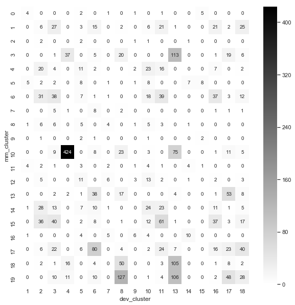

```python
fig,ax=plt.subplots(figsize=(10,10))
fig=sns.heatmap(pd.crosstab(df1['mm_cluster'], df1['dev_cluster']),annot=True, fmt='d',cmap='binary')
```

There are many cells in the cross tab frequency table of micromarket cluster and developer cluster with zeroes and ones. Both clusters together explain maximum variation in prices. We shall explore again with better data with a greater number of projects.

### 2.4 Looking At Correlations Between Word Embeddings Continuous Variables

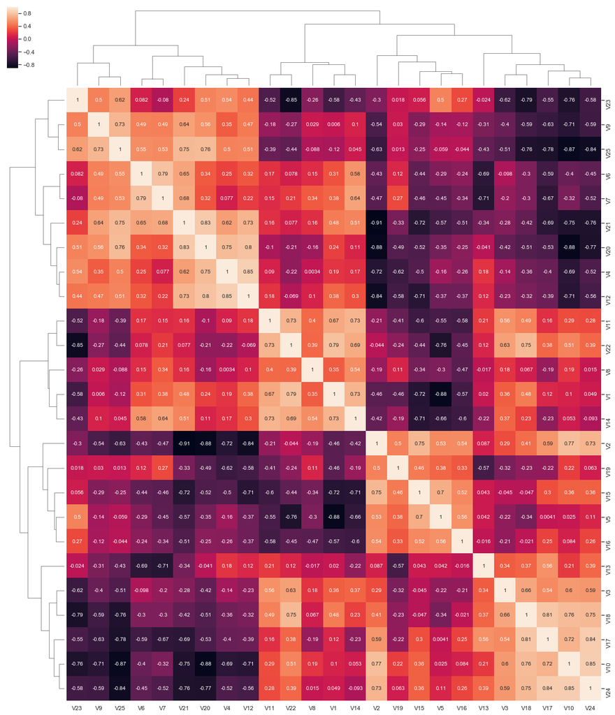

```python
# Dendogram Linkage between continuous variables showing links based on correlation coefficients
sns.clustermap(pd.DataFrame(df1.loc[:,'V1':'V25']).corr(),annot=True, method='complete',figsize=(20, 24))
```

Based on clustermap, it is suggested that following variables should not be used together in regression:

1) V9 and V25

2) V6 and V7

3) V4 and V12

4) V11 and V22

5) V1 and V14

7) V3 and V18

8) V10 and V24

```python
def calculate_vif (inc, dataframe): # Function for calculating and returning VIF values
    from statsmodels.stats.outliers_influence import variance_inflation_factor
    from statsmodels.tools.tools import add_constant

    df_vif=dataframe[inc]
    df_vifx = add_constant(df_vif)
    print('--Calculated VIF values--')
    return (pd.Series([variance_inflation_factor(df_vifx.values, i) for i in range(df_vifx.shape[1])], index=df_vifx.columns))
```

```python
include=list(df1.loc[:,'V1':'V25'])
calculate_vif (include, df1)
```

```
--Calculated VIF values--
```

```
const    11.061160
V1       16.276111
V2       35.742615
V3        5.886969
V4       10.097221
V5       12.720544
V6        6.987264
V7       14.762687
V8        3.866375
V9        4.633038
V10      52.346913
V11       9.601220
V12      13.100774
V13       7.794146
V14      12.688428
V15      10.552678
V16       4.936356
V17      23.588315
V18      13.935412
V19       9.781191
V20      35.438059
V21      57.255728
V22      24.142975
V23      26.708897
V24      12.709548
V25      22.332535
dtype: float64
```

Normally, VIF values greater than 5 is a concern for multicollinearity. The word embedding features, when used together, show high level of multicollinearity. It's up to our discretion which features should not be used together at a time and be dropped based on the values above.

## 3. Linear Regression Models with Word Embeddings

There are 4 possible models to be tried out.

### 3.1 Model 1

```python
import statsmodels.formula.api as smf
import statsmodels.api as sm

mod = smf.ols(formula='log_wap ~ C(mm_cluster) + C(dev_cluster) + b2 + b3 + b5 + bp1 + bp4 + V1 + V2 + V4 + V6 + V7 + V13 + V14 + V16 + V23 + V24', data=df1).fit()
print(mod.summary())
```

```
                            OLS Regression Results
==============================================================================
Dep. Variable:                log_wap   R-squared:                       0.945
Model:                            OLS   Adj. R-squared:                  0.944
Method:                 Least Squares   F-statistic:                     882.2
Date:                Thu, 14 Mar 2019   Prob (F-statistic):               0.00
Time:                        11:06:09   Log-Likelihood:                 743.43
No. Observations:                2621   AIC:                            -1385.
Df Residuals:                    2570   BIC:                            -1085.
Df Model:                          50
Covariance Type:            nonrobust
========================================================================================
                           coef    std err          t      P>|t|      [0.025      0.975]
----------------------------------------------------------------------------------------
Intercept               10.6199      0.065    163.080      0.000      10.492      10.748
C(mm_cluster)[T.1]      -0.6658      0.062    -10.812      0.000      -0.787      -0.545
C(mm_cluster)[T.2]      -0.1198      0.090     -1.327      0.184      -0.297       0.057
C(mm_cluster)[T.3]      -1.4482      0.063    -22.997      0.000      -1.572      -1.325
C(mm_cluster)[T.4]      -0.4255      0.061     -6.919      0.000      -0.546      -0.305
C(mm_cluster)[T.5]      -0.0874      0.059     -1.474      0.140      -0.204       0.029
C(mm_cluster)[T.6]      -0.5461      0.060     -9.040      0.000      -0.665      -0.428
C(mm_cluster)[T.7]      -0.9159      0.074    -12.451      0.000      -1.060      -0.772
C(mm_cluster)[T.8]      -0.2530      0.066     -3.855      0.000      -0.382      -0.124
C(mm_cluster)[T.9]       0.0323      0.087      0.369      0.712      -0.139       0.204
C(mm_cluster)[T.10]     -1.6105      0.063    -25.699      0.000      -1.733      -1.488
C(mm_cluster)[T.11]     -0.0912      0.067     -1.371      0.171      -0.222       0.039
C(mm_cluster)[T.12]     -0.1842      0.063     -2.916      0.004      -0.308      -0.060
C(mm_cluster)[T.13]     -1.0717      0.063    -17.002      0.000      -1.195      -0.948
C(mm_cluster)[T.14]     -0.4957      0.061     -8.163      0.000      -0.615      -0.377
C(mm_cluster)[T.15]     -0.6137      0.060    -10.145      0.000      -0.732      -0.495
C(mm_cluster)[T.16]     -0.2095      0.067     -3.140      0.002      -0.340      -0.079
C(mm_cluster)[T.17]     -0.8684      0.061    -14.252      0.000      -0.988      -0.749
C(mm_cluster)[T.18]     -1.3679      0.063    -21.731      0.000      -1.491      -1.244
C(mm_cluster)[T.19]     -1.2924      0.062    -20.855      0.000      -1.414      -1.171
C(dev_cluster)[T.2]     -0.3019      0.055     -5.496      0.000      -0.410      -0.194
C(dev_cluster)[T.3]     -0.5364      0.055     -9.707      0.000      -0.645      -0.428
C(dev_cluster)[T.4]     -0.9741      0.058    -16.870      0.000      -1.087      -0.861
C(dev_cluster)[T.5]     -0.2040      0.055     -3.714      0.000      -0.312      -0.096
C(dev_cluster)[T.6]     -0.6209      0.056    -11.039      0.000      -0.731      -0.511
C(dev_cluster)[T.7]     -0.1408      0.065     -2.178      0.030      -0.268      -0.014
```

[output cut: 21 more lines]

```
V14                     -0.0007      0.060     -0.012      0.991      -0.118       0.116
V16                      0.1779      0.070      2.533      0.011       0.040       0.316
V23                     -0.1635      0.060     -2.710      0.007      -0.282      -0.045
V24                     -0.2265      0.073     -3.100      0.002      -0.370      -0.083
==============================================================================
Omnibus:                      183.033   Durbin-Watson:                   1.706
Prob(Omnibus):                  0.000   Jarque-Bera (JB):              912.682
Skew:                          -0.004   Prob(JB):                    6.51e-199
Kurtosis:                       5.891   Cond. No.                     7.76e+03
==============================================================================

Warnings:
[1] Standard Errors assume that the covariance matrix of the errors is correctly specified.
[2] The condition number is large, 7.76e+03. This might indicate that there are
strong multicollinearity or other numerical problems.
```

Let us look at Variance Inflation Factors of the variables under consideration.

As mentioned by others and in this post at https://github.com/statsmodels/statsmodels/issues/2376 by Josef Perktold, the function's author, variance_inflation_factor expects the presence of a constant in the matrix of explanatory variables. One can use add_constant from statsmodels to add the required constant to the dataframe before passing its values to the function

```python
include=['mm_cluster','dev_cluster','b2','b3','b5','bp1','bp4','V1','V2','V4','V6','V7','V13','V14','V16','V23','V24']
calculate_vif (include, df1)
```

```
--Calculated VIF values--
```

```
const          19.845483
mm_cluster      1.028860
dev_cluster     1.038503
b2              1.201269
b3              1.145589
b5              1.034356
bp1             1.250852
bp4             1.126696
V1              6.643413
V2              8.706999
V4              4.439324
V6              4.803198
V7              6.861937
V13             4.306652
V14             5.077516
V16             2.379674
V23             7.518796
V24             6.462350
dtype: float64
```

Good to note that micromarket and developer clusters are not correlated.

```python
def residual_log (model, dataframe, residual_log, residual):
    # Function To Compute and return residual summary statistics for a model
    predicted_lwap = model.predict()
    predicted_wap=np.exp(predicted_lwap)
    dataframe[residual_log]=dataframe['log_wap'] - predicted_lwap
    dataframe[residual]=dataframe['wap'] - predicted_wap
    return (print(dataframe[residual_log].describe()),print ('median:  ',dataframe[residual_log].median()))
```

```python
residual_log (mod, df1, 'residual_log_mod','residual_mod') # Residual summmary statistics for model 1
```

```
count    2.621000e+03
mean     4.761700e-14
std      1.822470e-01
min     -1.045034e+00
25%     -9.953771e-02
50%      1.313921e-03
75%      1.003043e-01
max      1.003550e+00
Name: residual_log_mod, dtype: float64
median:   0.0013139206995980146
```

```
(None, None)
```

```python
def percentage_error_projects (dataframe, residual, percentage_error,percentage_error_interval):
    #Calculate percentage error w.r.t wap
    dataframe[percentage_error]=(dataframe[residual]/dataframe['wap'])*100
    #Split percentage error into equal intervals
    dataframe[percentage_error_interval] = pd.cut(dataframe[percentage_error], bins=[-float("inf"),-30,-20,-10,0,10,20,30,float("inf")])
    # How many projects in each interval of wap?
    grouped_df = dataframe.groupby(percentage_error_interval)['project_number'].count().reset_index()
    # Percentage of projects under each interval
    grouped_df['percentage_projects']=(grouped_df['project_number']/grouped_df['project_number'].sum())*100
    return (grouped_df)
```

```python
percentage_error_projects (df1, 'residual_mod', 'percentage_error_mod','percentage_error_mod_interval') # Model 1
```

|  | percentage_error_mod_interval | project_number | percentage_projects |
| --- | --- | --- | --- |
| 0 | (-inf, -30.0] | 168 | 6.409767 |
| 1 | (-30.0, -20.0] | 156 | 5.951927 |
| 2 | (-20.0, -10.0] | 356 | 13.582602 |
| 3 | (-10.0, 0.0] | 624 | 23.807707 |
| 4 | (0.0, 10.0] | 695 | 26.516597 |
| 5 | (10.0, 20.0] | 398 | 15.185044 |
| 6 | (20.0, 30.0] | 157 | 5.990080 |
| 7 | (30.0, inf] | 67 | 2.556276 |

```python
# Mean Absolute Percentage Error of model 1
np.absolute(df1['percentage_error_mod']).mean()
```

```
13.67296925842313
```

```python
# Split up wap into intervals
df1['wap_interval'] = pd.cut(df1['wap'], bins=[0,5e+3,1e+4,3e+4,9e+4])
df1['wap_interval'].value_counts()
```

```
(0.0, 5000.0]         1017
(10000.0, 30000.0]     927
(5000.0, 10000.0]      565
(30000.0, 90000.0]     112
Name: wap_interval, dtype: int64
```

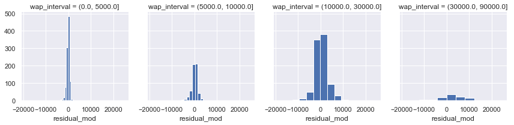

```python
g = sns.FacetGrid(df1, col="wap_interval")
g = g.map(plt.hist, "residual_mod")
```

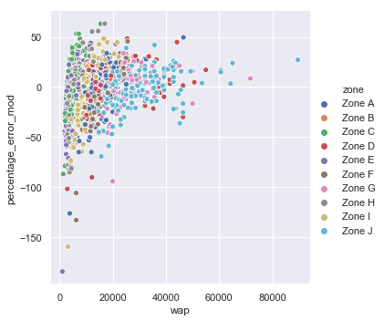

```python
sns.relplot(x="wap", y="percentage_error_mod", hue="zone", data=df1)
```

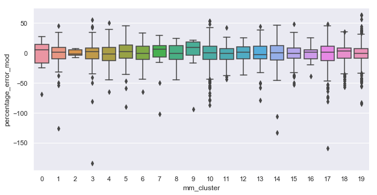

```python
f, ax = plt.subplots(figsize=(10,5))
sns.boxplot(x="mm_cluster", y="percentage_error_mod", data=df1)
```

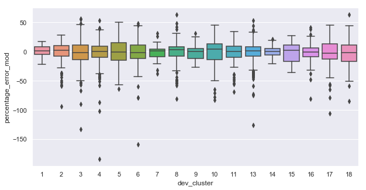

```python
f, ax = plt.subplots(figsize=(10,5))
sns.boxplot(x="dev_cluster", y="percentage_error_mod", data=df1)
```

### 3.2 Model 2

```python
mod2 = smf.ols(formula='log_wap ~ C(mm_cluster) + C(dev_cluster) + b2 + b3 + b5 + bp1 + bp4 + C(construction_status)', data=df1).fit()
print(mod2.summary())
```

```
                            OLS Regression Results
==============================================================================
Dep. Variable:                log_wap   R-squared:                       0.944
Model:                            OLS   Adj. R-squared:                  0.943
Method:                 Least Squares   F-statistic:                     1037.
Date:                Thu, 14 Mar 2019   Prob (F-statistic):               0.00
Time:                        11:06:11   Log-Likelihood:                 723.83
No. Observations:                2621   AIC:                            -1362.
Df Residuals:                    2578   BIC:                            -1109.
Df Model:                          42
Covariance Type:            nonrobust
================================================================================================================
                                                   coef    std err          t      P>|t|      [0.025      0.975]
----------------------------------------------------------------------------------------------------------------
Intercept                                       10.6551      0.065    164.541      0.000      10.528      10.782
C(mm_cluster)[T.1]                              -0.6681      0.062    -10.792      0.000      -0.789      -0.547
C(mm_cluster)[T.2]                              -0.1292      0.091     -1.425      0.154      -0.307       0.049
C(mm_cluster)[T.3]                              -1.4442      0.063    -22.816      0.000      -1.568      -1.320
C(mm_cluster)[T.4]                              -0.4238      0.062     -6.855      0.000      -0.545      -0.303
C(mm_cluster)[T.5]                              -0.0829      0.059     -1.394      0.163      -0.199       0.034
C(mm_cluster)[T.6]                              -0.5484      0.061     -9.027      0.000      -0.668      -0.429
C(mm_cluster)[T.7]                              -0.9027      0.074    -12.217      0.000      -1.048      -0.758
C(mm_cluster)[T.8]                              -0.2537      0.066     -3.845      0.000      -0.383      -0.124
C(mm_cluster)[T.9]                               0.0261      0.088      0.298      0.766      -0.146       0.198
C(mm_cluster)[T.10]                             -1.6136      0.063    -25.620      0.000      -1.737      -1.490
C(mm_cluster)[T.11]                             -0.0929      0.067     -1.392      0.164      -0.224       0.038
C(mm_cluster)[T.12]                             -0.1798      0.063     -2.838      0.005      -0.304      -0.056
C(mm_cluster)[T.13]                             -1.0723      0.063    -16.929      0.000      -1.197      -0.948
C(mm_cluster)[T.14]                             -0.4989      0.061     -8.172      0.000      -0.619      -0.379
C(mm_cluster)[T.15]                             -0.6142      0.061    -10.103      0.000      -0.733      -0.495
C(mm_cluster)[T.16]                             -0.2034      0.067     -3.037      0.002      -0.335      -0.072
C(mm_cluster)[T.17]                             -0.8624      0.061    -14.082      0.000      -0.982      -0.742
C(mm_cluster)[T.18]                             -1.3647      0.063    -21.575      0.000      -1.489      -1.241
C(mm_cluster)[T.19]                             -1.2900      0.062    -20.711      0.000      -1.412      -1.168
C(dev_cluster)[T.2]                             -0.3043      0.055     -5.510      0.000      -0.413      -0.196
C(dev_cluster)[T.3]                             -0.5482      0.055     -9.886      0.000      -0.657      -0.439
C(dev_cluster)[T.4]                             -0.9817      0.058    -16.920      0.000      -1.095      -0.868
C(dev_cluster)[T.5]                             -0.2076      0.055     -3.760      0.000      -0.316      -0.099
C(dev_cluster)[T.6]                             -0.6340      0.056    -11.232      0.000      -0.745      -0.523
C(dev_cluster)[T.7]                             -0.1412      0.065     -2.174      0.030      -0.269      -0.014
```

[output cut: 13 more lines]

```
b3                                            1.551e-05   7.62e-05      0.203      0.839      -0.000       0.000
b5                                               0.0045      0.003      1.753      0.080      -0.001       0.009
bp1                                             -0.1251      0.012    -10.125      0.000      -0.149      -0.101
bp4                                              0.2176      0.036      6.092      0.000       0.148       0.288
==============================================================================
Omnibus:                      187.435   Durbin-Watson:                   1.683
Prob(Omnibus):                  0.000   Jarque-Bera (JB):              958.678
Skew:                          -0.003   Prob(JB):                    6.69e-209
Kurtosis:                       5.963   Cond. No.                     7.75e+03
==============================================================================

Warnings:
[1] Standard Errors assume that the covariance matrix of the errors is correctly specified.
[2] The condition number is large, 7.75e+03. This might indicate that there are
strong multicollinearity or other numerical problems.
```

```python
def label_encoder(dataframe, col_name): # Function for label encoding categorical variables
    from sklearn.preprocessing import LabelEncoder
    le = LabelEncoder()
    le.fit(dataframe[col_name].unique())
    dataframe[col_name] = le.transform(dataframe[col_name])
```

```python
include=['mm_cluster','dev_cluster','b2','b3','b5','bp1','bp4','construction_status']
sel=pd.DataFrame(df1[include])
label_encoder(sel, 'construction_status')
calculate_vif (include, sel)
```

```
--Calculated VIF values--
```

```
const                  14.162576
mm_cluster              1.028241
dev_cluster             1.033505
b2                      1.185540
b3                      1.141813
b5                      1.033323
bp1                     1.211340
bp4                     1.113330
construction_status     1.030947
dtype: float64
```

```python
residual_log (mod2, df1, 'residual_log_mod2','residual_mod2') # Residual summary statistics for model 2
```

```
count    2.621000e+03
mean     8.957691e-15
std      1.836153e-01
min     -1.078507e+00
25%     -9.906742e-02
50%      3.407233e-03
75%      1.015341e-01
max      1.030156e+00
Name: residual_log_mod2, dtype: float64
median:   0.0034072332280530304
```

```
(None, None)
```

```python
percentage_error_projects (df1, 'residual_mod2', 'percentage_error_mod2','percentage_error_mod2_interval') # Model 2
```

|  | percentage_error_mod2_interval | project_number | percentage_projects |
| --- | --- | --- | --- |
| 0 | (-inf, -30.0] | 172 | 6.562381 |
| 1 | (-30.0, -20.0] | 171 | 6.524227 |
| 2 | (-20.0, -10.0] | 335 | 12.781381 |
| 3 | (-10.0, 0.0] | 606 | 23.120946 |
| 4 | (0.0, 10.0] | 702 | 26.783670 |
| 5 | (10.0, 20.0] | 406 | 15.490271 |
| 6 | (20.0, 30.0] | 159 | 6.066387 |
| 7 | (30.0, inf] | 70 | 2.670736 |

```python
# Mean Absolute Percentage Error of model 2
np.absolute(df1['percentage_error_mod2']).mean()
```

```
13.733171514354565
```

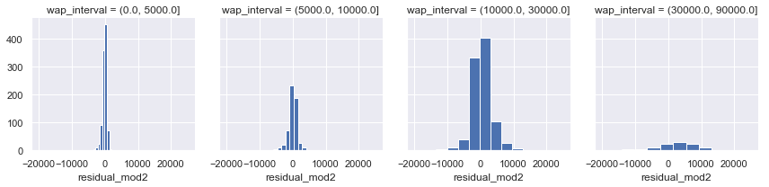

```python
g = sns.FacetGrid(df1, col="wap_interval")
g = g.map(plt.hist, "residual_mod2")
```

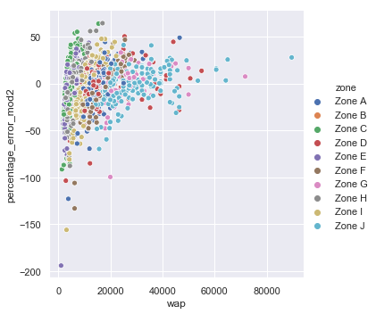

```python
sns.relplot(x="wap", y="percentage_error_mod2", hue="zone", data=df1)
```

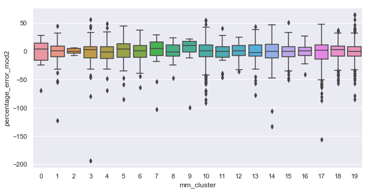

```python
f, ax = plt.subplots(figsize=(10,5))
sns.boxplot(x="mm_cluster", y="percentage_error_mod2", data=df1)
```

### 3.3 Model 3

```python
mod3 = smf.ols(formula='log_wap ~ C(mm_cluster) + b2 + b5 + bp1 + bp4 + bp58 + size_rv + V5 + V6 + V7 + V8 + V12 + V13 + V16 + V17 + V23 + V24 + V25', data=df1).fit()
print(mod3.summary())
```

```
                            OLS Regression Results
==============================================================================
Dep. Variable:                log_wap   R-squared:                       0.923
Model:                            OLS   Adj. R-squared:                  0.922
Method:                 Least Squares   F-statistic:                     857.6
Date:                Thu, 14 Mar 2019   Prob (F-statistic):               0.00
Time:                        11:06:14   Log-Likelihood:                 299.99
No. Observations:                2621   AIC:                            -526.0
Df Residuals:                    2584   BIC:                            -308.7
Df Model:                          36
Covariance Type:            nonrobust
=======================================================================================
                          coef    std err          t      P>|t|      [0.025      0.975]
---------------------------------------------------------------------------------------
Intercept              10.5769      0.062    169.257      0.000      10.454      10.699
C(mm_cluster)[T.1]     -1.0866      0.064    -17.046      0.000      -1.212      -0.962
C(mm_cluster)[T.2]     -0.2806      0.102     -2.756      0.006      -0.480      -0.081
C(mm_cluster)[T.3]     -2.1690      0.063    -34.413      0.000      -2.293      -2.045
C(mm_cluster)[T.4]     -0.7084      0.065    -10.973      0.000      -0.835      -0.582
C(mm_cluster)[T.5]     -0.1718      0.068     -2.531      0.011      -0.305      -0.039
C(mm_cluster)[T.6]     -0.9028      0.062    -14.460      0.000      -1.025      -0.780
C(mm_cluster)[T.7]     -1.4843      0.079    -18.866      0.000      -1.639      -1.330
C(mm_cluster)[T.8]     -0.5030      0.072     -7.024      0.000      -0.643      -0.363
C(mm_cluster)[T.9]     -0.1397      0.101     -1.381      0.167      -0.338       0.059
C(mm_cluster)[T.10]    -2.4456      0.062    -39.546      0.000      -2.567      -2.324
C(mm_cluster)[T.11]    -0.2073      0.075     -2.753      0.006      -0.355      -0.060
C(mm_cluster)[T.12]    -0.3964      0.068     -5.826      0.000      -0.530      -0.263
C(mm_cluster)[T.13]    -1.6525      0.064    -25.895      0.000      -1.778      -1.527
C(mm_cluster)[T.14]    -0.8262      0.063    -13.060      0.000      -0.950      -0.702
C(mm_cluster)[T.15]    -0.9855      0.062    -15.840      0.000      -1.107      -0.863
C(mm_cluster)[T.16]    -0.2922      0.072     -4.065      0.000      -0.433      -0.151
C(mm_cluster)[T.17]    -1.3593      0.062    -21.812      0.000      -1.481      -1.237
C(mm_cluster)[T.18]    -2.0568      0.063    -32.677      0.000      -2.180      -1.933
C(mm_cluster)[T.19]    -1.9239      0.062    -31.015      0.000      -2.046      -1.802
b2                     -0.0002   5.16e-05     -3.808      0.000      -0.000   -9.54e-05
b5                     -0.0068      0.004     -1.662      0.097      -0.015       0.001
bp1                    -0.1872      0.014    -13.137      0.000      -0.215      -0.159
bp4                     0.2594      0.041      6.254      0.000       0.178       0.341
bp58                    0.7820      0.245      3.197      0.001       0.302       1.262
size_rv                 0.0064      0.003      2.111      0.035       0.000       0.012
V5                      0.1201      0.079      1.516      0.130      -0.035       0.275
V6                      0.1237      0.067      1.835      0.067      -0.008       0.256
V7                     -0.1570      0.099     -1.580      0.114      -0.352       0.038
V8                     -0.0947      0.083     -1.136      0.256      -0.258       0.069
V12                     0.0202      0.056      0.361      0.718      -0.089       0.130
V13                     0.2576      0.099      2.604      0.009       0.064       0.451
V16                     0.1827      0.091      2.003      0.045       0.004       0.362
V17                    -0.0831      0.079     -1.050      0.294      -0.238       0.072
V23                    -0.3627      0.087     -4.167      0.000      -0.533      -0.192
V24                    -0.3844      0.091     -4.223      0.000      -0.563      -0.206
V25                     0.0438      0.075      0.580      0.562      -0.104       0.192
==============================================================================
Omnibus:                      193.859   Durbin-Watson:                   1.692
Prob(Omnibus):                  0.000   Jarque-Bera (JB):             1022.057
Skew:                          -0.039   Prob(JB):                    1.16e-222
Kurtosis:                       6.058   Cond. No.                     6.56e+03
==============================================================================

Warnings:
[1] Standard Errors assume that the covariance matrix of the errors is correctly specified.
[2] The condition number is large, 6.56e+03. This might indicate that there are
strong multicollinearity or other numerical problems.
```

```python
include=['mm_cluster','b2','b5','bp1','bp4','bp58','size_rv','V5','V6','V7','V8','V12','V13','V16','V17','V23','V24','V25']
calculate_vif (include, df1)
```

```
--Calculated VIF values--
```

```
const         18.222027
mm_cluster     1.016925
b2             1.158499
b5             1.916920
bp1            1.213455
bp4            1.128338
bp58           1.916171
size_rv        1.037322
V5             4.748517
V6             4.284363
V7             8.799639
V8             1.827404
V12            4.712740
V13            4.127877
V16            2.878439
V17           11.156851
V23           11.326199
V24            7.239115
V25            5.914779
dtype: float64
```

```python
print(residual_log (mod3, df1, 'residual_log_mod3','residual_mod3')) # Residual summary statistics for model 3
```

```
count    2.621000e+03
mean     9.987687e-14
std      2.158432e-01
min     -1.198906e+00
25%     -1.273301e-01
50%      1.472301e-03
75%      1.233548e-01
max      1.186073e+00
Name: residual_log_mod3, dtype: float64
median:   0.0014723011940613873
(None, None)
```

```python
percentage_error_projects (df1, 'residual_mod3', 'percentage_error_mod3','percentage_error_mod3_interval') # Model 3
```

|  | percentage_error_mod3_interval | project_number | percentage_projects |
| --- | --- | --- | --- |
| 0 | (-inf, -30.0] | 239 | 9.118657 |
| 1 | (-30.0, -20.0] | 201 | 7.668829 |
| 2 | (-20.0, -10.0] | 350 | 13.353682 |
| 3 | (-10.0, 0.0] | 515 | 19.648989 |
| 4 | (0.0, 10.0] | 588 | 22.434185 |
| 5 | (10.0, 20.0] | 420 | 16.024418 |
| 6 | (20.0, 30.0] | 197 | 7.516215 |
| 7 | (30.0, inf] | 111 | 4.235025 |

```python
# Mean Absolute Percentage Error of model 3
np.absolute(df1['percentage_error_mod3']).mean()
```

```
16.292461676346722
```

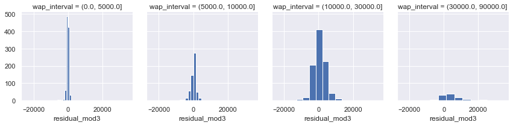

```python
g = sns.FacetGrid(df1, col="wap_interval")
g = g.map(plt.hist, "residual_mod3")
```

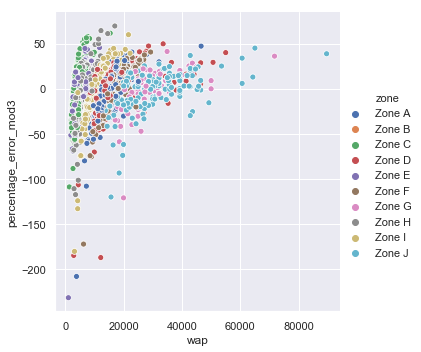

```python
sns.relplot(x="wap", y="percentage_error_mod3", hue="zone", data=df1)
```

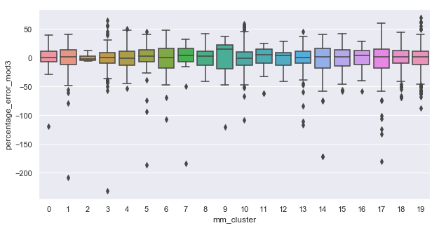

```python
f, ax = plt.subplots(figsize=(10,5))
sns.boxplot(x="mm_cluster", y="percentage_error_mod3", data=df1)
```

### 3.4 Model 4

```python
mod4 = smf.ols(formula='log_wap ~ C(mm_cluster) + C(dev_cluster) + b2 + bp1 + bp3 + bp4 + bp58 + size_rv + V4 + V5 + V6 + V7 + V8 + V12 + V13 + V16 + V17 + V23 + V24', data=df1).fit()
print(mod4.summary())
```

```
                            OLS Regression Results
==============================================================================
Dep. Variable:                log_wap   R-squared:                       0.945
Model:                            OLS   Adj. R-squared:                  0.944
Method:                 Least Squares   F-statistic:                     856.5
Date:                Thu, 14 Mar 2019   Prob (F-statistic):               0.00
Time:                        11:06:16   Log-Likelihood:                 756.40
No. Observations:                2621   AIC:                            -1407.
Df Residuals:                    2568   BIC:                            -1096.
Df Model:                          52
Covariance Type:            nonrobust
========================================================================================
                           coef    std err          t      P>|t|      [0.025      0.975]
----------------------------------------------------------------------------------------
Intercept               10.5769      0.065    161.583      0.000      10.449      10.705
C(mm_cluster)[T.1]      -0.6580      0.061    -10.727      0.000      -0.778      -0.538
C(mm_cluster)[T.2]      -0.1223      0.090     -1.361      0.173      -0.298       0.054
C(mm_cluster)[T.3]      -1.4487      0.063    -23.110      0.000      -1.572      -1.326
C(mm_cluster)[T.4]      -0.4246      0.061     -6.936      0.000      -0.545      -0.305
C(mm_cluster)[T.5]      -0.0886      0.059     -1.500      0.134      -0.204       0.027
C(mm_cluster)[T.6]      -0.5393      0.060     -8.967      0.000      -0.657      -0.421
C(mm_cluster)[T.7]      -0.9066      0.073    -12.368      0.000      -1.050      -0.763
C(mm_cluster)[T.8]      -0.2470      0.065     -3.778      0.000      -0.375      -0.119
C(mm_cluster)[T.9]       0.0122      0.087      0.140      0.889      -0.159       0.183
C(mm_cluster)[T.10]     -1.6093      0.062    -25.799      0.000      -1.732      -1.487
C(mm_cluster)[T.11]     -0.0853      0.066     -1.288      0.198      -0.215       0.045
C(mm_cluster)[T.12]     -0.1756      0.063     -2.794      0.005      -0.299      -0.052
C(mm_cluster)[T.13]     -1.0692      0.063    -17.042      0.000      -1.192      -0.946
C(mm_cluster)[T.14]     -0.4942      0.060     -8.176      0.000      -0.613      -0.376
C(mm_cluster)[T.15]     -0.6131      0.060    -10.188      0.000      -0.731      -0.495
C(mm_cluster)[T.16]     -0.2122      0.067     -3.186      0.001      -0.343      -0.082
C(mm_cluster)[T.17]     -0.8640      0.061    -14.249      0.000      -0.983      -0.745
C(mm_cluster)[T.18]     -1.3642      0.063    -21.777      0.000      -1.487      -1.241
C(mm_cluster)[T.19]     -1.2887      0.062    -20.894      0.000      -1.410      -1.168
C(dev_cluster)[T.2]     -0.2907      0.055     -5.292      0.000      -0.398      -0.183
C(dev_cluster)[T.3]     -0.5251      0.055     -9.504      0.000      -0.633      -0.417
C(dev_cluster)[T.4]     -0.9583      0.058    -16.611      0.000      -1.071      -0.845
C(dev_cluster)[T.5]     -0.2061      0.055     -3.761      0.000      -0.314      -0.099
C(dev_cluster)[T.6]     -0.6089      0.056    -10.839      0.000      -0.719      -0.499
C(dev_cluster)[T.7]     -0.1385      0.065     -2.145      0.032      -0.265      -0.012
```

[output cut: 23 more lines]

```
V16                      0.2099      0.076      2.774      0.006       0.061       0.358
V17                     -0.1435      0.069     -2.065      0.039      -0.280      -0.007
V23                     -0.2291      0.070     -3.266      0.001      -0.367      -0.092
V24                     -0.2333      0.069     -3.357      0.001      -0.370      -0.097
==============================================================================
Omnibus:                      181.577   Durbin-Watson:                   1.698
Prob(Omnibus):                  0.000   Jarque-Bera (JB):              896.776
Skew:                          -0.017   Prob(JB):                    1.85e-195
Kurtosis:                       5.865   Cond. No.                     7.60e+03
==============================================================================

Warnings:
[1] Standard Errors assume that the covariance matrix of the errors is correctly specified.
[2] The condition number is large, 7.6e+03. This might indicate that there are
strong multicollinearity or other numerical problems.
```

```python
include=['mm_cluster','dev_cluster','b2','bp1','bp3','bp4','bp58','size_rv','V4','V5','V6','V7','V8','V12','V13','V16','V17','V23','V24']
calculate_vif (include, df1)
```

```
--Calculated VIF values--
```

```
const          23.741391
mm_cluster      1.031722
dev_cluster     1.039058
b2              1.227176
bp1             1.888848
bp3             1.621526
bp4             1.130279
bp58            1.045870
size_rv         1.036360
V4              5.073528
V5              4.513881
V6              4.420996
V7              9.087150
V8              1.838295
V12             7.386885
V13             4.422621
V16             2.772962
V17            12.083058
V23            10.242987
V24             5.820136
dtype: float64
```

```python
print(residual_log (mod4, df1, 'residual_log_mod4','residual_mod4')) # Residual summary statistics for model 4
```

```
count    2.621000e+03
mean     1.223843e-13
std      1.813477e-01
min     -1.045954e+00
25%     -1.012554e-01
50%      4.223714e-03
75%      9.899466e-02
max      9.900227e-01
Name: residual_log_mod4, dtype: float64
median:   0.004223714188899663
(None, None)
```

```python
percentage_error_projects (df1, 'residual_mod4', 'percentage_error_mod4','percentage_error_mod4_interval') # Model 3
```

|  | percentage_error_mod4_interval | project_number | percentage_projects |
| --- | --- | --- | --- |
| 0 | (-inf, -30.0] | 169 | 6.447921 |
| 1 | (-30.0, -20.0] | 150 | 5.723006 |
| 2 | (-20.0, -10.0] | 371 | 14.154903 |
| 3 | (-10.0, 0.0] | 595 | 22.701259 |
| 4 | (0.0, 10.0] | 715 | 27.279664 |
| 5 | (10.0, 20.0] | 395 | 15.070584 |
| 6 | (20.0, 30.0] | 160 | 6.104540 |
| 7 | (30.0, inf] | 66 | 2.518123 |

```python
# Mean Absolute Percentage Error of model 4
np.absolute(df1['percentage_error_mod4']).mean()
```

```
13.599602714858364
```

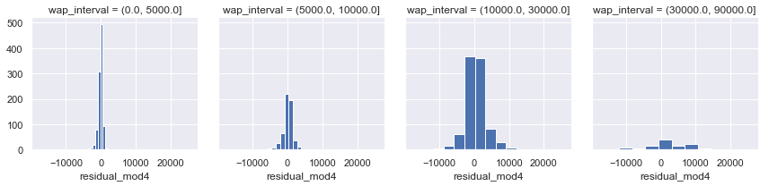

```python
g = sns.FacetGrid(df1, col="wap_interval")
g = g.map(plt.hist, "residual_mod4")
```

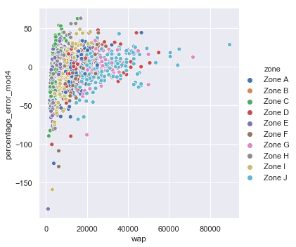

```python
sns.relplot(x="wap", y="percentage_error_mod4", hue="zone", data=df1)
```

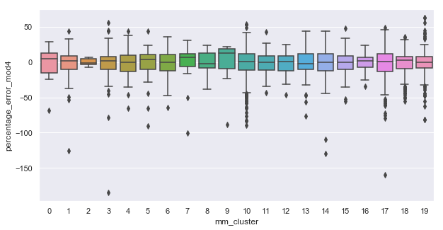

```python
f, ax = plt.subplots(figsize=(10,5))
sns.boxplot(x="mm_cluster", y="percentage_error_mod4", data=df1)
```

## 4. Back-Testing

When we backtest a predictive model, we are testing how the model performs over a period of time. Model performance is know to degenerate over time.

Train data - entries for 2014, 2015 and 2016

Test data - entries for 2017, 2018

```python
df1_train=pd.concat([df1.loc[(df1['launch_year'] == 2014), :],df1.loc[(df1['launch_year'] == 2015), :],df1.loc[(df1['launch_year'] == 2016), :]],axis=0)
df1_train.head(10)
```

|  | zone | micro_market_number | developer_number | project_number | wap | log_wap | proj_bedrooms_clean | unit_type | proj_launched_units | launch_year | ... | percentage_error_mod2 | percentage_error_mod2_interval | residual_log_mod3 | residual_mod3 | percentage_error_mod3 | percentage_error_mod3_interval | residual_log_mod4 | residual_mod4 | percentage_error_mod4 | percentage_error_mod4_interval |
| --- | --- | --- | --- | --- | --- | --- | --- | --- | --- | --- | --- | --- | --- | --- | --- | --- | --- | --- | --- | --- | --- |
| 1 | Zone A | 1 | 2 | 2 | 13982.0000 | 9.545526 | 2 and more | Apartment | 150 | 2014 | ... | -10.322027 | (-20.0, -10.0] | -0.142103 | -2134.981253 | -15.269498 | (-20.0, -10.0] | -0.095573 | -1402.246594 | -10.028941 | (-20.0, -10.0] |
| 2 | Zone A | 1 | 2 | 3 | 13982.0000 | 9.545526 | 2 and more | Apartment | 150 | 2014 | ... | -10.322027 | (-20.0, -10.0] | -0.124769 | -1858.021160 | -13.288665 | (-20.0, -10.0] | -0.083134 | -1212.060822 | -8.668723 | (-10.0, 0.0] |
| 5 | Zone A | 1 | 8 | 9 | 12000.0000 | 9.392662 | 2 and more | Apartment | 78 | 2014 | ... | -16.847832 | (-20.0, -10.0] | -0.351177 | -5048.864736 | -42.073873 | (-inf, -30.0] | -0.189503 | -2503.788955 | -20.864908 | (-30.0, -20.0] |
| 7 | Zone A | 1 | 13 | 16 | 18500.0000 | 9.825526 | 1 and more | Apartment | 35 | 2014 | ... | 13.526837 | (10.0, 20.0] | 0.291475 | 4677.525439 | 25.283921 | (20.0, 30.0] | 0.140265 | 2421.128703 | 13.087182 | (10.0, 20.0] |
| 9 | Zone A | 1 | 15 | 18 | 13750.0000 | 9.528794 | 1 and more | Apartment | 54 | 2014 | ... | -4.538919 | (-10.0, 0.0] | -0.043828 | -616.030053 | -4.480219 | (-10.0, 0.0] | -0.034595 | -484.008453 | -3.520061 | (-10.0, 0.0] |
| 10 | Zone A | 1 | 15 | 19 | 14000.0000 | 9.546813 | 1 and more | Apartment | 140 | 2014 | ... | -2.945334 | (-10.0, 0.0] | -0.045599 | -653.165225 | -4.665466 | (-10.0, 0.0] | -0.024867 | -352.497535 | -2.517840 | (-10.0, 0.0] |
| 12 | Zone A | 1 | 22 | 27 | 11500.0000 | 9.350102 | 1 and more | Apartment | 146 | 2014 | ... | -23.271461 | (-30.0, -20.0] | -0.211372 | -2706.770877 | -23.537138 | (-30.0, -20.0] | -0.164584 | -2057.381361 | -17.890273 | (-20.0, -10.0] |
| 18 | Zone A | 1 | 31 | 44 | 14043.2471 | 9.549897 | 1 and more | Apartment | 595 | 2014 | ... | -19.994571 | (-20.0, -10.0] | -0.093915 | -1382.792651 | -9.846673 | (-10.0, 0.0] | -0.215078 | -3369.796323 | -23.995849 | (-30.0, -20.0] |
| 22 | Zone A | 1 | 37 | 53 | 12500.0000 | 9.433484 | 1 and more | Apartment | 105 | 2014 | ... | -3.612013 | (-10.0, 0.0] | -0.165289 | -2246.678726 | -17.973430 | (-20.0, -10.0] | -0.065200 | -842.157295 | -6.737258 | (-10.0, 0.0] |
| 23 | Zone A | 1 | 38 | 54 | 12351.6364 | 9.421544 | 1 and more | Apartment | 99 | 2014 | ... | -12.268646 | (-20.0, -10.0] | -0.263966 | -3731.223592 | -30.208334 | (-inf, -30.0] | -0.150026 | -1999.283885 | -16.186389 | (-20.0, -10.0] |

10 rows × 77 columns

```python
df1_test=pd.concat([df1.loc[(df1['launch_year'] == 2017), :],df1.loc[(df1['launch_year'] == 2018), :]],axis=0)
df1_test.head(10)
```

|  | zone | micro_market_number | developer_number | project_number | wap | log_wap | proj_bedrooms_clean | unit_type | proj_launched_units | launch_year | ... | percentage_error_mod2 | percentage_error_mod2_interval | residual_log_mod3 | residual_mod3 | percentage_error_mod3 | percentage_error_mod3_interval | residual_log_mod4 | residual_mod4 | percentage_error_mod4 | percentage_error_mod4_interval |
| --- | --- | --- | --- | --- | --- | --- | --- | --- | --- | --- | --- | --- | --- | --- | --- | --- | --- | --- | --- | --- | --- |
| 6 | Zone A | 1 | 9 | 10 | 13885.0000 | 9.538564 | 1 and more | Apartment | 46 | 2017 | ... | -0.459966 | (-10.0, 0.0] | 0.020551 | 282.434102 | 2.034095 | (0.0, 10.0] | -0.015892 | -222.420024 | -1.601873 | (-10.0, 0.0] |
| 16 | Zone A | 1 | 28 | 35 | 14502.0000 | 9.582042 | 2 and more | Apartment | 87 | 2017 | ... | 4.218852 | (0.0, 10.0] | -0.166861 | -2633.421427 | -18.159022 | (-20.0, -10.0] | -0.008547 | -124.478680 | -0.858355 | (-10.0, 0.0] |
| 17 | Zone A | 1 | 28 | 36 | 14502.0000 | 9.582042 | 2 and more | Apartment | 77 | 2017 | ... | 3.971596 | (0.0, 10.0] | -0.190383 | -3041.256533 | -20.971290 | (-30.0, -20.0] | -0.004935 | -71.745863 | -0.494731 | (-10.0, 0.0] |
| 20 | Zone A | 1 | 35 | 50 | 14464.0000 | 9.579418 | 2 and more | Apartment | 36 | 2017 | ... | 1.054694 | (0.0, 10.0] | -0.143722 | -2235.595077 | -15.456271 | (-20.0, -10.0] | 0.001881 | 27.178031 | 0.187901 | (0.0, 10.0] |
| 21 | Zone A | 1 | 35 | 51 | 14464.0000 | 9.579418 | 2 and more | Apartment | 36 | 2017 | ... | 1.054694 | (0.0, 10.0] | -0.129102 | -1993.222248 | -13.780574 | (-20.0, -10.0] | 0.053437 | 752.629817 | 5.203469 | (0.0, 10.0] |
| 34 | Zone A | 1 | 59 | 86 | 18041.7021 | 9.800441 | 1 and more | Apartment | 423 | 2017 | ... | 10.673382 | (10.0, 20.0] | 0.226369 | 3654.817336 | 20.257608 | (20.0, 30.0] | 0.111868 | 1909.499848 | 10.583812 | (10.0, 20.0] |
| 41 | Zone A | 1 | 69 | 98 | 20177.0000 | 9.912299 | 1 and more | Apartment | 430 | 2017 | ... | 20.714006 | (20.0, 30.0] | 0.449570 | 7306.045159 | 36.209769 | (30.0, inf] | 0.278203 | 4900.116358 | 24.285654 | (20.0, 30.0] |
| 43 | Zone A | 1 | 71 | 102 | 17678.0000 | 9.780076 | 1 and more | Apartment | 25 | 2017 | ... | 5.927830 | (0.0, 10.0] | 0.171908 | 2792.123583 | 15.794341 | (10.0, 20.0] | 0.048817 | 842.264212 | 4.764477 | (0.0, 10.0] |
| 54 | Zone A | 2 | 96 | 135 | 25000.0000 | 10.126631 | 3 and more | Apartment | 93 | 2017 | ... | 15.229099 | (10.0, 20.0] | 0.103247 | 2452.391647 | 9.809567 | (0.0, 10.0] | 0.120099 | 2829.193863 | 11.316775 | (10.0, 20.0] |
| 57 | Zone A | 2 | 101 | 141 | 18500.0000 | 9.825526 | 1 and more | Apartment | 154 | 2017 | ... | -2.045570 | (-10.0, 0.0] | 0.020835 | 381.457725 | 2.061934 | (0.0, 10.0] | -0.004696 | -87.072830 | -0.470664 | (-10.0, 0.0] |

10 rows × 77 columns

Let's backtest the models we worked with earlier individually.

#### 4.1 Backtesting model 1

```python
backt = smf.ols(formula='log_wap ~ C(mm_cluster) + C(dev_cluster) + b2 + b3 + b5 + bp1 + bp4 + V1 + V2 + V4 + V6 + V7 + V13 + V14 + V16 + V23 + V24', data=df1_train).fit()
print(backt.summary())
```

```
                            OLS Regression Results
==============================================================================
Dep. Variable:                log_wap   R-squared:                       0.953
Model:                            OLS   Adj. R-squared:                  0.952
Method:                 Least Squares   F-statistic:                     799.9
Date:                Thu, 14 Mar 2019   Prob (F-statistic):               0.00
Time:                        11:06:19   Log-Likelihood:                 733.05
No. Observations:                2009   AIC:                            -1364.
Df Residuals:                    1958   BIC:                            -1078.
Df Model:                          50
Covariance Type:            nonrobust
========================================================================================
                           coef    std err          t      P>|t|      [0.025      0.975]
----------------------------------------------------------------------------------------
Intercept               10.6723      0.064    167.021      0.000      10.547      10.798
C(mm_cluster)[T.1]      -0.7560      0.063    -12.089      0.000      -0.879      -0.633
C(mm_cluster)[T.2]      -0.2255      0.137     -1.641      0.101      -0.495       0.044
C(mm_cluster)[T.3]      -1.5473      0.065    -23.984      0.000      -1.674      -1.421
C(mm_cluster)[T.4]      -0.5490      0.062     -8.832      0.000      -0.671      -0.427
C(mm_cluster)[T.5]      -0.1233      0.060     -2.061      0.039      -0.241      -0.006
C(mm_cluster)[T.6]      -0.6383      0.061    -10.449      0.000      -0.758      -0.519
C(mm_cluster)[T.7]      -0.9953      0.076    -13.017      0.000      -1.145      -0.845
C(mm_cluster)[T.8]      -0.3579      0.067     -5.319      0.000      -0.490      -0.226
C(mm_cluster)[T.9]      -0.0318      0.083     -0.384      0.701      -0.195       0.131
C(mm_cluster)[T.10]     -1.7260      0.064    -26.899      0.000      -1.852      -1.600
C(mm_cluster)[T.11]     -0.1747      0.067     -2.599      0.009      -0.307      -0.043
C(mm_cluster)[T.12]     -0.2723      0.063     -4.305      0.000      -0.396      -0.148
C(mm_cluster)[T.13]     -1.1732      0.064    -18.252      0.000      -1.299      -1.047
C(mm_cluster)[T.14]     -0.5897      0.062     -9.569      0.000      -0.711      -0.469
C(mm_cluster)[T.15]     -0.7119      0.062    -11.566      0.000      -0.833      -0.591
C(mm_cluster)[T.16]     -0.2931      0.067     -4.371      0.000      -0.425      -0.162
C(mm_cluster)[T.17]     -0.9569      0.062    -15.421      0.000      -1.079      -0.835
C(mm_cluster)[T.18]     -1.4846      0.064    -23.108      0.000      -1.611      -1.359
C(mm_cluster)[T.19]     -1.4199      0.063    -22.411      0.000      -1.544      -1.296
C(dev_cluster)[T.2]     -0.2542      0.057     -4.436      0.000      -0.367      -0.142
C(dev_cluster)[T.3]     -0.5080      0.058     -8.776      0.000      -0.621      -0.394
C(dev_cluster)[T.4]     -0.9029      0.061    -14.906      0.000      -1.022      -0.784
C(dev_cluster)[T.5]     -0.1766      0.057     -3.109      0.002      -0.288      -0.065
C(dev_cluster)[T.6]     -0.5845      0.059     -9.937      0.000      -0.700      -0.469
C(dev_cluster)[T.7]     -0.1149      0.067     -1.705      0.088      -0.247       0.017
```

[output cut: 21 more lines]

```
V14                     -0.0128      0.065     -0.198      0.843      -0.140       0.114
V16                      0.2009      0.071      2.810      0.005       0.061       0.341
V23                     -0.1584      0.061     -2.599      0.009      -0.278      -0.039
V24                     -0.1956      0.077     -2.545      0.011      -0.346      -0.045
==============================================================================
Omnibus:                      106.155   Durbin-Watson:                   1.691
Prob(Omnibus):                  0.000   Jarque-Bera (JB):              350.679
Skew:                          -0.162   Prob(JB):                     7.10e-77
Kurtosis:                       5.021   Cond. No.                     7.33e+03
==============================================================================

Warnings:
[1] Standard Errors assume that the covariance matrix of the errors is correctly specified.
[2] The condition number is large, 7.33e+03. This might indicate that there are
strong multicollinearity or other numerical problems.
```

Python's scikit-learn library's r2_score metric will be helpful for calculating R2 score regression metric by comparing values of two different datasets.

```python
def model_R2 (model):
    from sklearn.metrics import r2_score

    y_pred=model.predict(df1_test)
    return (r2_score(df1_test['log_wap'], y_pred))
```

```python
# R2 score of model 1 backtesting
print('R2 Score of Model 1:',model_R2 (backt))
```

```
R2 Score of Model 1: 0.9119568329372366
```

```python
def residual_computation (model, dataframe, residual_log, residual):
    # Function To Compute and return residual summary statistics for a model
    predicted_lwap = model.predict(dataframe)
    predicted_wap=np.exp(predicted_lwap)
    dataframe[residual_log]=dataframe['log_wap'] - predicted_lwap
    dataframe[residual]=dataframe['wap'] - predicted_wap
    return (dataframe[residual_log].describe(), print ('median:  ',dataframe[residual_log].median()))
```

```python
# Residual summary statistics of model 1 backtesting
residual_computation (backt, df1_test, 'residual_log_backt', 'residual_backt')
```

```
median:   0.051749997545741167
```

```
(count    612.000000
 mean       0.054601
 std        0.222924
 min       -1.052536
 25%       -0.056756
 50%        0.051750
 75%        0.166468
 max        1.064244
 Name: residual_log_backt, dtype: float64, None)
```

```python
# Percentage Error vs projects for model 1 backtesting
percentage_error_projects (df1_test, 'residual_backt', 'percentage_error_backt','percentage_error_backt_interval')
```

|  | percentage_error_backt_interval | project_number | percentage_projects |
| --- | --- | --- | --- |
| 0 | (-inf, -30.0] | 31 | 5.065359 |
| 1 | (-30.0, -20.0] | 35 | 5.718954 |
| 2 | (-20.0, -10.0] | 53 | 8.660131 |
| 3 | (-10.0, 0.0] | 113 | 18.464052 |
| 4 | (0.0, 10.0] | 156 | 25.490196 |
| 5 | (10.0, 20.0] | 120 | 19.607843 |
| 6 | (20.0, 30.0] | 66 | 10.784314 |
| 7 | (30.0, inf] | 38 | 6.209150 |

```python
# Mean Absolute Percentage Error of model 1 backtesting
np.absolute(df1_test['percentage_error_backt']).mean()
```

```
15.878434557177986
```

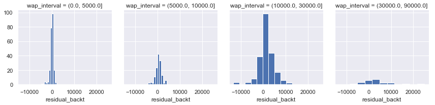

```python
g = sns.FacetGrid(df1_test, col="wap_interval")
g = g.map(plt.hist, "residual_backt")
```

#### 4.2 Backtesting model 2

```python
backt2 = smf.ols(formula='log_wap ~ C(mm_cluster) + C(dev_cluster) + b2 + b3 + b5 + bp1 + bp4 + C(construction_status)', data=df1_train).fit()
print(backt2.summary())
```

```
                            OLS Regression Results
==============================================================================
Dep. Variable:                log_wap   R-squared:                       0.952
Model:                            OLS   Adj. R-squared:                  0.951
Method:                 Least Squares   F-statistic:                     930.4
Date:                Thu, 14 Mar 2019   Prob (F-statistic):               0.00
Time:                        11:06:20   Log-Likelihood:                 706.90
No. Observations:                2009   AIC:                            -1328.
Df Residuals:                    1966   BIC:                            -1087.
Df Model:                          42
Covariance Type:            nonrobust
================================================================================================================
                                                   coef    std err          t      P>|t|      [0.025      0.975]
----------------------------------------------------------------------------------------------------------------
Intercept                                       10.7197      0.064    168.134      0.000      10.595      10.845
C(mm_cluster)[T.1]                              -0.7504      0.063    -11.881      0.000      -0.874      -0.627
C(mm_cluster)[T.2]                              -0.2336      0.138     -1.686      0.092      -0.505       0.038
C(mm_cluster)[T.3]                              -1.5313      0.065    -23.512      0.000      -1.659      -1.404
C(mm_cluster)[T.4]                              -0.5345      0.063     -8.517      0.000      -0.658      -0.411
C(mm_cluster)[T.5]                              -0.1128      0.060     -1.873      0.061      -0.231       0.005
C(mm_cluster)[T.6]                              -0.6322      0.062    -10.243      0.000      -0.753      -0.511
C(mm_cluster)[T.7]                              -0.9653      0.077    -12.520      0.000      -1.116      -0.814
C(mm_cluster)[T.8]                              -0.3552      0.068     -5.231      0.000      -0.488      -0.222
C(mm_cluster)[T.9]                              -0.0307      0.084     -0.366      0.714      -0.195       0.133
C(mm_cluster)[T.10]                             -1.7196      0.065    -26.551      0.000      -1.847      -1.593
C(mm_cluster)[T.11]                             -0.1705      0.068     -2.514      0.012      -0.303      -0.037
C(mm_cluster)[T.12]                             -0.2573      0.064     -4.039      0.000      -0.382      -0.132
C(mm_cluster)[T.13]                             -1.1714      0.065    -18.050      0.000      -1.299      -1.044
C(mm_cluster)[T.14]                             -0.5839      0.062     -9.378      0.000      -0.706      -0.462
C(mm_cluster)[T.15]                             -0.7032      0.062    -11.320      0.000      -0.825      -0.581
C(mm_cluster)[T.16]                             -0.2716      0.068     -4.021      0.000      -0.404      -0.139
C(mm_cluster)[T.17]                             -0.9394      0.063    -15.001      0.000      -1.062      -0.817
C(mm_cluster)[T.18]                             -1.4717      0.065    -22.691      0.000      -1.599      -1.344
C(mm_cluster)[T.19]                             -1.4070      0.064    -22.002      0.000      -1.532      -1.282
C(dev_cluster)[T.2]                             -0.2667      0.058     -4.608      0.000      -0.380      -0.153
C(dev_cluster)[T.3]                             -0.5394      0.058     -9.261      0.000      -0.654      -0.425
C(dev_cluster)[T.4]                             -0.9281      0.061    -15.189      0.000      -1.048      -0.808
C(dev_cluster)[T.5]                             -0.1995      0.057     -3.479      0.001      -0.312      -0.087
C(dev_cluster)[T.6]                             -0.6120      0.059    -10.321      0.000      -0.728      -0.496
C(dev_cluster)[T.7]                             -0.1308      0.068     -1.922      0.055      -0.264       0.003
```

[output cut: 13 more lines]

```
b3                                            3.729e-05   7.61e-05      0.490      0.624      -0.000       0.000
b5                                               0.0042      0.003      1.219      0.223      -0.003       0.011
bp1                                             -0.1382      0.013    -10.327      0.000      -0.164      -0.112
bp4                                              0.1957      0.035      5.533      0.000       0.126       0.265
==============================================================================
Omnibus:                      107.462   Durbin-Watson:                   1.670
Prob(Omnibus):                  0.000   Jarque-Bera (JB):              376.723
Skew:                          -0.128   Prob(JB):                     1.57e-82
Kurtosis:                       5.106   Cond. No.                     7.31e+03
==============================================================================

Warnings:
[1] Standard Errors assume that the covariance matrix of the errors is correctly specified.
[2] The condition number is large, 7.31e+03. This might indicate that there are
strong multicollinearity or other numerical problems.
```

```python
# R2 score of model 2 backtesting
print('R2 Score of Model 2:',model_R2 (backt2))
```

```
R2 Score of Model 2: 0.9131863461953461
```

```python
# Residual summary statistics of model 2 backtesting
residual_computation (backt2, df1_test, 'residual_log_backt2', 'residual_backt2')
```

```
median:   0.056273074327740424
```

```
(count    612.000000
 mean       0.056953
 std        0.220673
 min       -1.096548
 25%       -0.053285
 50%        0.056273
 75%        0.170044
 max        1.091325
 Name: residual_log_backt2, dtype: float64, None)
```

```python
# Percentage Error vs projects for model 2 backtesting
percentage_error_projects (df1_test, 'residual_backt2', 'percentage_error_backt2','percentage_error_backt2_interval')
```

|  | percentage_error_backt2_interval | project_number | percentage_projects |
| --- | --- | --- | --- |
| 0 | (-inf, -30.0] | 29 | 4.738562 |
| 1 | (-30.0, -20.0] | 32 | 5.228758 |
| 2 | (-20.0, -10.0] | 53 | 8.660131 |
| 3 | (-10.0, 0.0] | 107 | 17.483660 |
| 4 | (0.0, 10.0] | 162 | 26.470588 |
| 5 | (10.0, 20.0] | 122 | 19.934641 |
| 6 | (20.0, 30.0] | 69 | 11.274510 |
| 7 | (30.0, inf] | 38 | 6.209150 |

```python
# Mean Absolute Percentage Error of model 2 backtesting
np.absolute(df1_test['percentage_error_backt2']).mean()
```

```
15.765720307722422
```

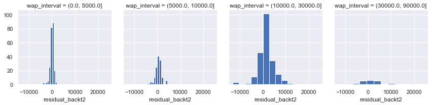

```python
g = sns.FacetGrid(df1_test, col="wap_interval")
g = g.map(plt.hist, "residual_backt2")
```

#### 4.3 Backtesting Model 3

```python
backt3 = smf.ols(formula='log_wap ~ C(mm_cluster) + b2 + b5 + bp1 + bp4 + bp58 + size_rv + V5 + V6 + V7 + V8 + V12 + V13 + V16 + V17 + V23 + V24 + V25', data=df1_train).fit()
print(backt3.summary())
```

```
                            OLS Regression Results
==============================================================================
Dep. Variable:                log_wap   R-squared:                       0.932
Model:                            OLS   Adj. R-squared:                  0.931
Method:                 Least Squares   F-statistic:                     752.1
Date:                Thu, 14 Mar 2019   Prob (F-statistic):               0.00
Time:                        11:06:21   Log-Likelihood:                 356.62
No. Observations:                2009   AIC:                            -639.2
Df Residuals:                    1972   BIC:                            -431.8
Df Model:                          36
Covariance Type:            nonrobust
=======================================================================================
                          coef    std err          t      P>|t|      [0.025      0.975]
---------------------------------------------------------------------------------------
Intercept              10.6662      0.062    172.382      0.000      10.545      10.788
C(mm_cluster)[T.1]     -1.1626      0.063    -18.348      0.000      -1.287      -1.038
C(mm_cluster)[T.2]     -0.2827      0.157     -1.801      0.072      -0.591       0.025
C(mm_cluster)[T.3]     -2.2480      0.063    -35.790      0.000      -2.371      -2.125
C(mm_cluster)[T.4]     -0.8213      0.064    -12.782      0.000      -0.947      -0.695
C(mm_cluster)[T.5]     -0.2196      0.069     -3.205      0.001      -0.354      -0.085
C(mm_cluster)[T.6]     -0.9832      0.062    -15.919      0.000      -1.104      -0.862
C(mm_cluster)[T.7]     -1.5579      0.081    -19.173      0.000      -1.717      -1.399
C(mm_cluster)[T.8]     -0.5645      0.074     -7.633      0.000      -0.710      -0.419
C(mm_cluster)[T.9]     -0.1911      0.097     -1.976      0.048      -0.381      -0.001
C(mm_cluster)[T.10]    -2.5239      0.062    -40.989      0.000      -2.645      -2.403
C(mm_cluster)[T.11]    -0.2888      0.077     -3.746      0.000      -0.440      -0.138
C(mm_cluster)[T.12]    -0.4834      0.068     -7.153      0.000      -0.616      -0.351
C(mm_cluster)[T.13]    -1.7254      0.064    -27.156      0.000      -1.850      -1.601
C(mm_cluster)[T.14]    -0.9057      0.063    -14.374      0.000      -1.029      -0.782
C(mm_cluster)[T.15]    -1.0799      0.062    -17.517      0.000      -1.201      -0.959
C(mm_cluster)[T.16]    -0.3831      0.072     -5.339      0.000      -0.524      -0.242
C(mm_cluster)[T.17]    -1.4265      0.062    -23.065      0.000      -1.548      -1.305
C(mm_cluster)[T.18]    -2.1462      0.062    -34.349      0.000      -2.269      -2.024
C(mm_cluster)[T.19]    -2.0196      0.062    -32.778      0.000      -2.140      -1.899
b2                     -0.0003    5.8e-05     -5.423      0.000      -0.000      -0.000
b5                     -0.0043      0.005     -0.876      0.381      -0.014       0.005
bp1                    -0.2100      0.016    -13.428      0.000      -0.241      -0.179
bp4                     0.2409      0.041      5.817      0.000       0.160       0.322
bp58                    0.3326      0.267      1.247      0.212      -0.190       0.855
size_rv                 0.0101      0.003      3.095      0.002       0.004       0.016
V5                      0.0461      0.084      0.549      0.583      -0.118       0.211
V6                      0.0523      0.069      0.753      0.451      -0.084       0.188
V7                     -0.2035      0.103     -1.971      0.049      -0.406      -0.001
V8                     -0.0985      0.088     -1.116      0.265      -0.272       0.075
V12                    -0.0357      0.059     -0.604      0.546      -0.152       0.080
V13                     0.2651      0.105      2.528      0.012       0.059       0.471
V16                     0.1566      0.095      1.653      0.099      -0.029       0.343
V17                    -0.0833      0.081     -1.031      0.303      -0.242       0.075
V23                    -0.2983      0.089     -3.346      0.001      -0.473      -0.123
V24                    -0.4570      0.096     -4.760      0.000      -0.645      -0.269
V25                     0.0188      0.078      0.241      0.810      -0.134       0.172
==============================================================================
Omnibus:                      122.115   Durbin-Watson:                   1.694
Prob(Omnibus):                  0.000   Jarque-Bera (JB):              502.065
Skew:                          -0.089   Prob(JB):                    9.51e-110
Kurtosis:                       5.443   Cond. No.                     5.98e+03
==============================================================================

Warnings:
[1] Standard Errors assume that the covariance matrix of the errors is correctly specified.
[2] The condition number is large, 5.98e+03. This might indicate that there are
strong multicollinearity or other numerical problems.
```

```python
# R2 score of model 3 backtesting
print('R2 Score of model 3:',model_R2 (backt3))
```

```
R2 Score of model 3: 0.88599986870568
```

```python
# Residual summary statistics of model 3 backtesting
residual_computation (backt3, df1_test, 'residual_log_backt3', 'residual_backt3')
```

```
median:   0.06654099790432255
```

```
(count    612.000000
 mean       0.065156
 std        0.252904
 min       -1.188392
 25%       -0.073433
 50%        0.066541
 75%        0.190988
 max        1.231372
 Name: residual_log_backt3, dtype: float64, None)
```

```python
# Percentage Error vs projects for model 3 backtesting
percentage_error_projects (df1_test, 'residual_backt3', 'percentage_error_backt3','percentage_error_backt3_interval')
```

|  | percentage_error_backt3_interval | project_number | percentage_projects |
| --- | --- | --- | --- |
| 0 | (-inf, -30.0] | 33 | 5.392157 |
| 1 | (-30.0, -20.0] | 35 | 5.718954 |
| 2 | (-20.0, -10.0] | 68 | 11.111111 |
| 3 | (-10.0, 0.0] | 90 | 14.705882 |
| 4 | (0.0, 10.0] | 126 | 20.588235 |
| 5 | (10.0, 20.0] | 135 | 22.058824 |
| 6 | (20.0, 30.0] | 71 | 11.601307 |
| 7 | (30.0, inf] | 54 | 8.823529 |

```python
# Mean Absolute Percentage Error of model 3 backtesting
np.absolute(df1_test['percentage_error_backt3']).mean()
```

```
18.314889319446966
```

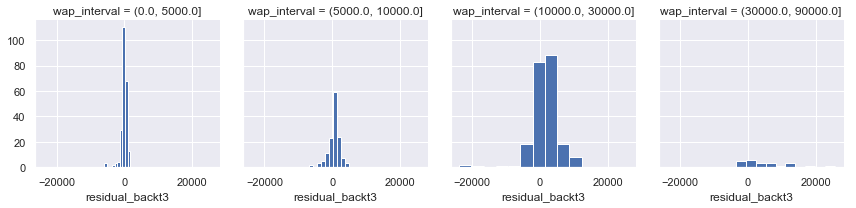

```python
g = sns.FacetGrid(df1_test, col="wap_interval")
g = g.map(plt.hist, "residual_backt3")
```

#### 4.4 Backtesting Model 4

```python
backt4 = smf.ols(formula='log_wap ~ C(mm_cluster) + C(dev_cluster) + b2 + bp1 + bp3 + bp4 + bp58 + size_rv + V4 + V5 + V6 + V7 + V8 + V12 + V13 + V16 + V17 + V23 + V24', data=df1_train).fit()
print(backt4.summary())
```

```
                            OLS Regression Results
==============================================================================
Dep. Variable:                log_wap   R-squared:                       0.954
Model:                            OLS   Adj. R-squared:                  0.952
Method:                 Least Squares   F-statistic:                     773.2
Date:                Thu, 14 Mar 2019   Prob (F-statistic):               0.00
Time:                        11:06:23   Log-Likelihood:                 739.01
No. Observations:                2009   AIC:                            -1372.
Df Residuals:                    1956   BIC:                            -1075.
Df Model:                          52
Covariance Type:            nonrobust
========================================================================================
                           coef    std err          t      P>|t|      [0.025      0.975]
----------------------------------------------------------------------------------------
Intercept               10.6390      0.065    164.430      0.000      10.512      10.766
C(mm_cluster)[T.1]      -0.7470      0.062    -11.957      0.000      -0.869      -0.624
C(mm_cluster)[T.2]      -0.2436      0.137     -1.775      0.076      -0.513       0.026
C(mm_cluster)[T.3]      -1.5486      0.064    -24.051      0.000      -1.675      -1.422
C(mm_cluster)[T.4]      -0.5461      0.062     -8.788      0.000      -0.668      -0.424
C(mm_cluster)[T.5]      -0.1278      0.060     -2.138      0.033      -0.245      -0.011
C(mm_cluster)[T.6]      -0.6304      0.061    -10.338      0.000      -0.750      -0.511
C(mm_cluster)[T.7]      -0.9873      0.076    -12.925      0.000      -1.137      -0.837
C(mm_cluster)[T.8]      -0.3559      0.067     -5.289      0.000      -0.488      -0.224
C(mm_cluster)[T.9]      -0.0383      0.083     -0.461      0.645      -0.201       0.125
C(mm_cluster)[T.10]     -1.7220      0.064    -26.891      0.000      -1.848      -1.596
C(mm_cluster)[T.11]     -0.1710      0.067     -2.548      0.011      -0.303      -0.039
C(mm_cluster)[T.12]     -0.2663      0.063     -4.221      0.000      -0.390      -0.143
C(mm_cluster)[T.13]     -1.1704      0.064    -18.245      0.000      -1.296      -1.045
C(mm_cluster)[T.14]     -0.5865      0.062     -9.532      0.000      -0.707      -0.466
C(mm_cluster)[T.15]     -0.7090      0.061    -11.552      0.000      -0.829      -0.589
C(mm_cluster)[T.16]     -0.3032      0.067     -4.513      0.000      -0.435      -0.171
C(mm_cluster)[T.17]     -0.9496      0.062    -15.341      0.000      -1.071      -0.828
C(mm_cluster)[T.18]     -1.4799      0.064    -23.085      0.000      -1.606      -1.354
C(mm_cluster)[T.19]     -1.4145      0.063    -22.374      0.000      -1.538      -1.290
C(dev_cluster)[T.2]     -0.2454      0.058     -4.260      0.000      -0.358      -0.132
C(dev_cluster)[T.3]     -0.5032      0.058     -8.663      0.000      -0.617      -0.389
C(dev_cluster)[T.4]     -0.8931      0.061    -14.702      0.000      -1.012      -0.774
C(dev_cluster)[T.5]     -0.1805      0.057     -3.173      0.002      -0.292      -0.069
C(dev_cluster)[T.6]     -0.5784      0.059     -9.806      0.000      -0.694      -0.463
C(dev_cluster)[T.7]     -0.1201      0.068     -1.777      0.076      -0.253       0.012
```

[output cut: 23 more lines]

```
V16                      0.1719      0.078      2.213      0.027       0.020       0.324
V17                     -0.1142      0.071     -1.620      0.105      -0.252       0.024
V23                     -0.1888      0.071     -2.655      0.008      -0.328      -0.049
V24                     -0.2839      0.072     -3.925      0.000      -0.426      -0.142
==============================================================================
Omnibus:                      105.510   Durbin-Watson:                   1.683
Prob(Omnibus):                  0.000   Jarque-Bera (JB):              350.274
Skew:                          -0.155   Prob(JB):                     8.69e-77
Kurtosis:                       5.022   Cond. No.                     7.11e+03
==============================================================================

Warnings:
[1] Standard Errors assume that the covariance matrix of the errors is correctly specified.
[2] The condition number is large, 7.11e+03. This might indicate that there are
strong multicollinearity or other numerical problems.
```

```python
# R2 score of model 4 backtesting
print('R2 Score of Model 4:',model_R2 (backt4))
```

```
R2 Score of Model 4: 0.913107617074447
```

```python
# Residual summary statistics of model 4 backtesting
residual_computation (backt4, df1_test, 'residual_log_backt4', 'residual_backt4')
```

```
median:   0.054377156422264594
```

```
(count    612.000000
 mean       0.058165
 std        0.220463
 min       -1.054108
 25%       -0.048121
 50%        0.054377
 75%        0.166470
 max        1.059332
 Name: residual_log_backt4, dtype: float64, None)
```

```python
# Percentage Error vs projects for model 4 backtesting
percentage_error_projects (df1_test, 'residual_backt4', 'percentage_error_backt4','percentage_error_backt4_interval')
```

|  | percentage_error_backt4_interval | project_number | percentage_projects |
| --- | --- | --- | --- |
| 0 | (-inf, -30.0] | 31 | 5.065359 |
| 1 | (-30.0, -20.0] | 21 | 3.431373 |
| 2 | (-20.0, -10.0] | 67 | 10.947712 |
| 3 | (-10.0, 0.0] | 95 | 15.522876 |
| 4 | (0.0, 10.0] | 171 | 27.941176 |
| 5 | (10.0, 20.0] | 126 | 20.588235 |
| 6 | (20.0, 30.0] | 64 | 10.457516 |
| 7 | (30.0, inf] | 37 | 6.045752 |

```python
# Mean Absolute Percentage Error of model 4 backtesting
np.absolute(df1_test['percentage_error_backt4']).mean()
```

```
15.768345645028912
```

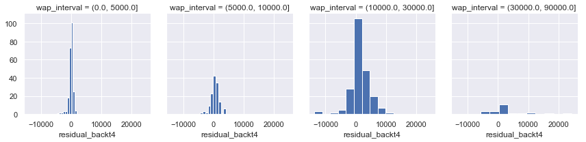

```python
g = sns.FacetGrid(df1_test, col="wap_interval")
g = g.map(plt.hist, "residual_backt4")
```

Model 4 is finalised.

#### 4.4 Regression Diagnostics of Final Model

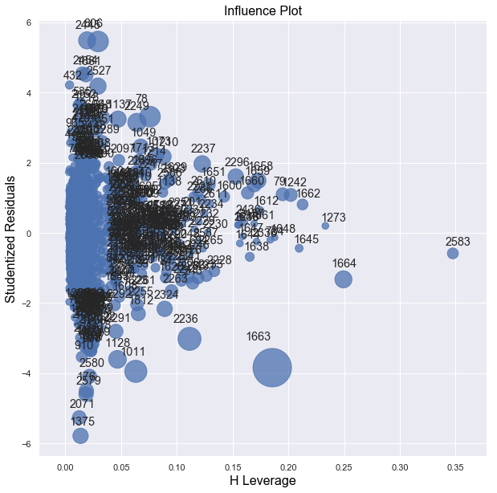

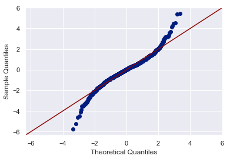

```python
fig,ax=plt.subplots(figsize=(10,10))
#Cook's Distance Plot for final model
fig=sm.graphics.influence_plot(mod4, ax=ax, color='b')
#QQ Plot for log-residual of final model showing deviation from normal distribution
fig = sm.qqplot(df1['residual_log_mod4'], fit=True, line='45')
plt.show()
```

## 5. Extreme Gradient Boost Regressor Using Final Model Features

```python
include=['log_wap','mm_cluster','dev_cluster','b2','bp1','bp3','bp4','bp58','size_rv','V4','V5','V6','V7','V8','V12','V13','V16','V17','V23','V24']
df2=pd.DataFrame(df1[include])

df2.head()
```

|  | log_wap | mm_cluster | dev_cluster | b2 | bp1 | bp3 | bp4 | bp58 | size_rv | V4 | V5 | V6 | V7 | V8 | V12 | V13 | V16 | V17 | V23 | V24 |
| --- | --- | --- | --- | --- | --- | --- | --- | --- | --- | --- | --- | --- | --- | --- | --- | --- | --- | --- | --- | --- |
| 0 | 9.579418 | 6 | 16 | 5 | 0.954955 | 0.000000 | 0.0 | 0.0 | 1.383353 | -0.067081 | -0.185371 | -0.032546 | 0.435810 | 0.264055 | -0.116487 | -0.252410 | -0.422871 | -0.789669 | -0.131723 | -0.580872 |
| 1 | 9.545526 | 6 | 16 | 98 | 0.000000 | 0.346667 | 0.0 | 0.0 | 0.372748 | 0.278550 | -0.111899 | 0.312749 | 0.307807 | -0.034639 | 0.294924 | -0.167680 | -0.056276 | -0.577943 | 0.348402 | -0.405855 |
| 2 | 9.545526 | 6 | 16 | 98 | 0.000000 | 0.346667 | 0.0 | 0.0 | 0.372748 | 0.282199 | -0.090756 | 0.292134 | 0.288563 | -0.021560 | 0.282619 | -0.137335 | -0.055074 | -0.553753 | 0.379972 | -0.367028 |
| 3 | 9.461644 | 6 | 3 | 13 | 0.891667 | 0.000000 | 0.0 | 0.0 | 1.187398 | 0.391827 | -0.249752 | 0.281397 | 0.277463 | 0.051048 | 0.525415 | -0.076936 | -0.174178 | -0.400852 | 0.150187 | -0.344659 |
| 4 | 9.739884 | 6 | 11 | 22 | 0.030303 | 0.303030 | 0.0 | 0.0 | 1.519184 | 0.307399 | -0.107702 | 0.292808 | 0.239444 | -0.048153 | 0.321322 | -0.099483 | -0.063372 | -0.468529 | 0.352715 | -0.367375 |

```python
from sklearn.model_selection import train_test_split

target = 'log_wap'
features = df2.columns != target
x = df2.loc[:,features]
y = df2[target]
x_train, x_test, y_train, y_test = train_test_split(x, y, random_state=8)
print(x_train.shape, x_test.shape, y_train.shape, y_test.shape)
```

```
(1965, 19) (656, 19) (1965,) (656,)
```

```python
import xgboost as xgb

xg_reg=xgb.XGBRegressor(base_score=0, objective='reg:linear',n_estimators=200,learning_rate=0.09,reg_alpha=5.5)
xg_reg.fit(x_train,y_train)
```

```
XGBRegressor(base_score=0, booster='gbtree', colsample_bylevel=1,
       colsample_bytree=1, gamma=0, learning_rate=0.09, max_delta_step=0,
       max_depth=3, min_child_weight=1, missing=None, n_estimators=200,
       n_jobs=1, nthread=None, objective='reg:linear', random_state=0,
       reg_alpha=5.5, reg_lambda=1, scale_pos_weight=1, seed=None,
       silent=True, subsample=1)
```

```python
from sklearn.model_selection import cross_validate, GridSearchCV

# cross validate
scores_xgreg = cross_validate(xg_reg, x_train, y_train, cv=8,
                        return_train_score=True,
                        return_estimator=False)
scores_xgreg=pd.DataFrame(scores_xgreg)
scores_xgreg
```

|  | fit_time | score_time | test_score | train_score |
| --- | --- | --- | --- | --- |
| 0 | 0.274664 | 0.000000 | 0.904333 | 0.922246 |
| 1 | 0.269512 | 0.000000 | 0.886194 | 0.922814 |
| 2 | 0.253822 | 0.000000 | 0.904618 | 0.920677 |
| 3 | 0.247446 | 0.015623 | 0.904770 | 0.923141 |
| 4 | 0.263087 | 0.000000 | 0.921976 | 0.920368 |
| 5 | 0.269618 | 0.000000 | 0.901823 | 0.920151 |
| 6 | 0.269655 | 0.000000 | 0.912295 | 0.921786 |
| 7 | 0.263154 | 0.000000 | 0.890154 | 0.923191 |

```python
print('Mean Test Score of XG Boost Regressor of final model: ', scores_xgreg['test_score'].mean())
print('Mean Train Score of XG Boost Regressor of final model: ', scores_xgreg['train_score'].mean())
```

```
Mean Test Score of XG Boost Regressor of final model:  0.9032704410706496
Mean Train Score of XG Boost Regressor of final model:  0.9217967992679376
```

```python
def model_r2score (model, x_testdataframe, y_testdataframe):
    from sklearn.metrics import r2_score

    y_predicted_values=model.predict(x_testdataframe)
    return (r2_score(y_testdataframe, y_predicted_values))
```

```python
print('R2 Score of XGBoost Regressor of Final Model:',model_r2score (xg_reg, x_test, y_test))
```

```
R2 Score of XGBoost Regressor of Final Model: 0.9086408486426835
```

```python
def plot_feature_importances (model, kind, title, color, dataframe):
    importances = pd.Series(data=model.feature_importances_, index= dataframe.columns)
    # Sort importances
    importances_sorted = importances.sort_values()
    # Draw a horizontal barplot of importances_sorted
    importances_sorted.plot(kind=kind, color=color)
    plt.title(title)
    return(plt.show())
```

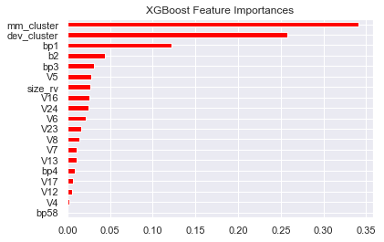

```python
plot_feature_importances (xg_reg, 'barh', 'XGBoost Feature Importances','red', x_train)
```

```python
def compute_residual (model, column, dataframe, xtest_dataframe, y_testdataframe):
    y_pred=model.predict(xtest_dataframe)
    y_pred_wap=np.exp(y_pred)
    y_actual_wap=np.exp(y_testdataframe)
    y_resid = y_actual_wap - y_pred_wap
    dataframe[column]=pd.DataFrame(y_resid)
    return(dataframe[column].describe())
```

```python
compute_residual (xg_reg, 'residual_xgreg', df1, x_test, y_test) #Residual statistics of XGBoost of final model
```

```
count      656.000000
mean       431.033967
std       3649.531657
min     -13042.810881
25%       -861.289917
50%        -37.568604
75%        711.733379
max      29073.621094
Name: residual_xgreg, dtype: float64
```

```python
# Percentage Error vs projects for XGBoost of final model
percentage_error_projects (df1, 'residual_xgreg', 'percentage_error_xgreg','percentage_error_interval_xgreg')
```

|  | percentage_error_interval_xgreg | project_number | percentage_projects |
| --- | --- | --- | --- |
| 0 | (-inf, -30.0] | 68 | 10.365854 |
| 1 | (-30.0, -20.0] | 53 | 8.079268 |
| 2 | (-20.0, -10.0] | 87 | 13.262195 |
| 3 | (-10.0, 0.0] | 132 | 20.121951 |
| 4 | (0.0, 10.0] | 145 | 22.103659 |
| 5 | (10.0, 20.0] | 92 | 14.024390 |
| 6 | (20.0, 30.0] | 46 | 7.012195 |
| 7 | (30.0, inf] | 33 | 5.030488 |

```python
# Mean Absolute Percentage Error of XG Boost Model residuals of final model
np.absolute(df1['percentage_error_xgreg']).mean()
```

```
17.195558573095735
```

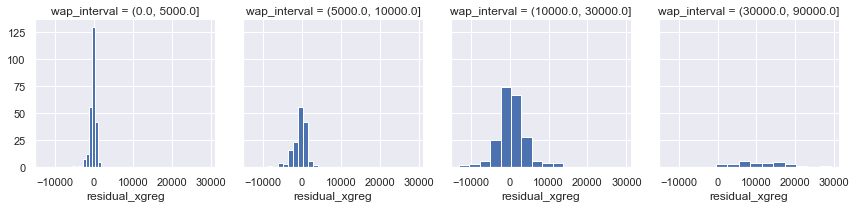

```python
g = sns.FacetGrid(df1, col="wap_interval")
g = g.map(plt.hist, "residual_xgreg")
```

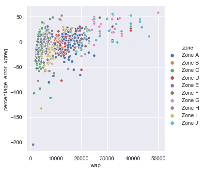

```python
sns.relplot(x="wap", y="percentage_error_xgreg", hue="zone", data=df1)
```

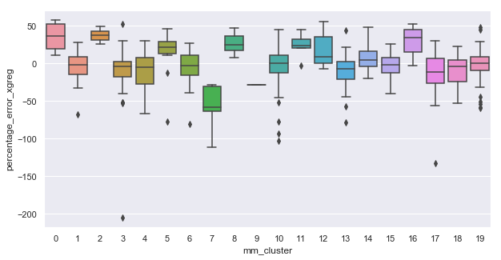

```python
f, ax = plt.subplots(figsize=(10,5))
sns.boxplot(x="mm_cluster", y="percentage_error_xgreg", data=df1)
```

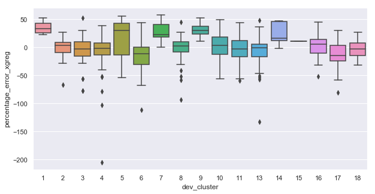

```python
f, ax = plt.subplots(figsize=(10,5))
sns.boxplot(x="dev_cluster", y="percentage_error_xgreg", data=df1)
```

Linear Regression outperforms Extreme Gradient Boosting algorithm.